# Sadržaj

```python
%%javascript
$.getScript('https://kmahelona.github.io/ipython_notebook_goodies/ipython_notebook_toc.js')
```

# Vizualizacija podataka u Pythonu

## Uvod

Zašto je bitna vizualizacija podataka?

1. Jer nam omogućava da kompleksne podatke u grafičkoj formi koja je lakša za razumevanje. Ovo je posebno značajno prilikom istraživanja podataka.
2. Prikazuje jasnu sliku samih podataka
3. Olakša deljenje nepristrasnih reprezentacija podataka
4. Može se koristiti kao podrška za predloge koji se daju ključnim donosiocima odluka

Takođe, vizuelizacija podataka je samo jedan od koraka u razumevanju podataka i izvlačenju vrednosti iz njih. Iako je samo jedan deo procesa, ključan je za svakog ko radi sa podacima u smislu da nam skraćuje vreme jer ukoliko primetimo nešto vredno istraživanja u podacima kroz njihovu vizuelizaciju, to je potencijalno problem koji se u narednim koracima dodatno istražuje.

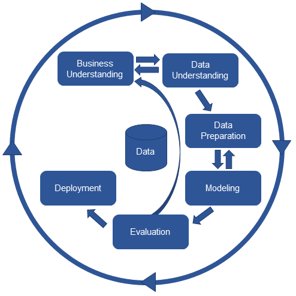

Postoji veliki broj biblioteka koje se bave vizuelizacijom podataka u Pythonu:

1. Matplotlib
2. Seaborn
3. Bokeh
4. Altair
5. Plotly
6. Ggplot
7. Geoplotlib
8. Gleam
9. Pygal
10. Missingno i mnoge druge

Postoji grafici koji se bave prikazivanjem različitih stvari: korelacije, devijacije, rangova, distribucije, kompozicije, promena i grupacija.

Kroz ovaj seminarski rad pokazaćemo grafike iz Matplotlib, Seaborn, Folium biblioteka, i iako se može dosta pisati na ovu temu jer postoji pregršt funkcija, zadržaćemo se na onim koje su najčešće korišćene. Pri tome smatramo da je efektivan grafik onaj koji:

1. Prikazuje potrebne podatke bez iskrivljene slike
2. Jednostavnog dizajna i lak za razumevanje
3. Estetika ne sakriva već podržava informacije
4. Nije prenatrpan informacijama.

## Korišćeni dataset

Dataset koji će biti korišćen u vizuelizacijama: Međunarodni migracioni tokovi u i iz odabranih zemalja - revizija 2015.

Dataset sadrži godišnje podatke o boju imigranata zabeleženih u zemljama odredišta. Poadaci prikazuju i prilive i odlive prema mestu rodjenja, državljanstvu ili mestu prethodnog prebivališta, kako za strance tako i za državljane. Korišćena verzija sadrži podatke koji se odnose na 45 zemalja.

U ovom radu fokusiraćemo se na Kanadske podatke o imigraciji:

[figure not shown]

Prvih dvadeset redova sadrže tekstualne i druge nebitne podatke, dvadeset i prvi red sadrži nazive kolona. Svaki red predstavlja jednu temlju i sadrži podatke o toj zemlji kao što su kontinent, regija, i da li je u pitanju razvijena ili regija u razvoju. Slede podaci o ukupnom broju imigranata od 1980- 2013.

## Pandas biblioteka

Jedna od najkorišćenijih Python biblioteka, posebno kada je u pitanju data science oblast i osnovni priručnik za analizu podataka u Pythonu je pandas. Sa njihove veb stranice:

```
Pandas je Python paket koji pruža brze, fleksibilne i izražajne strukture podataka dizajnirane da olakšaju i intuitivno rade sa „relacionim“ ili „označenim“ podacima. Cilj mu je da bude osnovni gradivni element na visokom nivou za obavljanje praktične, stvarne analize podataka u Pithonu.
```

Ključne karakteristike odnosno prednosti ove biblioteke su:

- Velika podrška i jaka zajednica
- Aktivno se razvija
- Ima opsežnu [dokumentaciju](https://pandas.pydata.org/pandas-docs/stable/index.html#)
- Odlično radi sa ostalim bibliotekama kao na primer sa Scikit Learn za mašinsko učenje
- Izgrađena na NumPy zbog čega je jako brza

Neke od osnovnih funkcionalnosti koje se mogu naći u Pandas biblioteci su:

- Import i export podataka u različitim formatima (CSV, Txt, Excel, SQL, HDF5)
- Statistika
- Indexiranje, sortiranje, rangiranje
- Čišćenje podataka
- Filtriranje
- Grupisanje (GroupBy)
- Pivot
- Rad sa vremenskim serijama (time series)
- Vizualizacija podataka

## Uvoz i analiza podataka

Prvo što je neophodno uraditi je importovati numpy i pandas biblioteke

```python
import numpy as np
import pandas as pd
```

Za korišćenje metode read_excel() u pandas biblioteci, potrebno je instalirati modul xlrd

```
!conda install -c anaconda xlrd --yes
```

```python
df_can = pd.read_excel('data/Canada.xlsx',
                        sheet_name='Canada by Citizenship',
                        skiprows=range(20),
                        skipfooter=2)

print ('Podaci su učitani u dataframe!')
```

```
Podaci su učitani u dataframe!
```

```python
df_can.head()
```

|  | Type | Coverage | OdName | AREA | AreaName | REG | RegName | DEV | DevName | 1980 | ... | 2004 | 2005 | 2006 | 2007 | 2008 | 2009 | 2010 | 2011 | 2012 | 2013 |
| --- | --- | --- | --- | --- | --- | --- | --- | --- | --- | --- | --- | --- | --- | --- | --- | --- | --- | --- | --- | --- | --- |
| 0 | Immigrants | Foreigners | Afghanistan | 935 | Asia | 5501 | Southern Asia | 902 | Developing regions | 16 | ... | 2978 | 3436 | 3009 | 2652 | 2111 | 1746 | 1758 | 2203 | 2635 | 2004 |
| 1 | Immigrants | Foreigners | Albania | 908 | Europe | 925 | Southern Europe | 901 | Developed regions | 1 | ... | 1450 | 1223 | 856 | 702 | 560 | 716 | 561 | 539 | 620 | 603 |
| 2 | Immigrants | Foreigners | Algeria | 903 | Africa | 912 | Northern Africa | 902 | Developing regions | 80 | ... | 3616 | 3626 | 4807 | 3623 | 4005 | 5393 | 4752 | 4325 | 3774 | 4331 |
| 3 | Immigrants | Foreigners | American Samoa | 909 | Oceania | 957 | Polynesia | 902 | Developing regions | 0 | ... | 0 | 0 | 1 | 0 | 0 | 0 | 0 | 0 | 0 | 0 |
| 4 | Immigrants | Foreigners | Andorra | 908 | Europe | 925 | Southern Europe | 901 | Developed regions | 0 | ... | 0 | 0 | 1 | 1 | 0 | 0 | 0 | 0 | 1 | 1 |

5 rows × 43 columns

Analiziraćemo dataset i osnovne informacije o njemu.

```python
df_can.info(verbose=False) #osnovne informacije dataseta
df_can.shape #veličina dataseta (redovi,kolone)
```

```
<class 'pandas.core.frame.DataFrame'>
RangeIndex: 195 entries, 0 to 194
Columns: 43 entries, Type to 2013
dtypes: int64(37), object(6)
memory usage: 65.6+ KB
```

```
(195, 43)
```

```python
df_can.columns.values #nazivi atributa, odnosno kolona dataseta
```

```
array(['Type', 'Coverage', 'OdName', 'AREA', 'AreaName', 'REG', 'RegName',
       'DEV', 'DevName', 1980, 1981, 1982, 1983, 1984, 1985, 1986, 1987,
       1988, 1989, 1990, 1991, 1992, 1993, 1994, 1995, 1996, 1997, 1998,
       1999, 2000, 2001, 2002, 2003, 2004, 2005, 2006, 2007, 2008, 2009,
       2010, 2011, 2012, 2013], dtype=object)
```

```python
df_can.isnull().sum() #proveravamo da li ima nedostajućih (null) vrednosti u datasetu
```

```
Type        0
Coverage    0
OdName      0
AREA        0
AreaName    0
REG         0
RegName     0
DEV         0
DevName     0
1980        0
1981        0
1982        0
1983        0
1984        0
1985        0
```

[output cut: 29 more lines]

```python
df_can.describe() #parametri numeričkih vrednosti u datasetu
```

|  | AREA | REG | DEV | 1980 | 1981 | 1982 | 1983 | 1984 | 1985 | 1986 | ... | 2004 | 2005 | 2006 | 2007 | 2008 | 2009 | 2010 | 2011 | 2012 | 2013 |
| --- | --- | --- | --- | --- | --- | --- | --- | --- | --- | --- | --- | --- | --- | --- | --- | --- | --- | --- | --- | --- | --- |
| count | 195.000000 | 195.000000 | 195.000000 | 195.000000 | 195.000000 | 195.000000 | 195.000000 | 195.000000 | 195.000000 | 195.000000 | ... | 195.000000 | 195.000000 | 195.000000 | 195.000000 | 195.000000 | 195.000000 | 195.000000 | 195.000000 | 195.000000 | 195.000000 |
| mean | 912.764103 | 1249.015385 | 901.753846 | 508.394872 | 566.989744 | 534.723077 | 387.435897 | 376.497436 | 358.861538 | 441.271795 | ... | 1190.169231 | 1320.292308 | 1266.958974 | 1191.820513 | 1246.394872 | 1275.733333 | 1420.287179 | 1262.533333 | 1313.958974 | 1320.702564 |
| std | 13.082835 | 1185.526885 | 0.431878 | 1949.588546 | 2152.643752 | 1866.997511 | 1204.333597 | 1198.246371 | 1079.309600 | 1225.576630 | ... | 3710.505369 | 4425.957828 | 3926.717747 | 3443.542409 | 3694.573544 | 3829.630424 | 4462.946328 | 4030.084313 | 4247.555161 | 4237.951988 |
| min | 903.000000 | 905.000000 | 901.000000 | 0.000000 | 0.000000 | 0.000000 | 0.000000 | 0.000000 | 0.000000 | 0.000000 | ... | 0.000000 | 0.000000 | 0.000000 | 0.000000 | 0.000000 | 0.000000 | 0.000000 | 0.000000 | 0.000000 | 0.000000 |
| 25% | 903.000000 | 914.000000 | 902.000000 | 0.000000 | 0.000000 | 0.000000 | 0.000000 | 0.000000 | 0.000000 | 0.500000 | ... | 19.000000 | 28.500000 | 25.000000 | 31.000000 | 31.000000 | 36.000000 | 40.500000 | 37.500000 | 42.500000 | 45.000000 |
| 50% | 908.000000 | 922.000000 | 902.000000 | 13.000000 | 10.000000 | 11.000000 | 12.000000 | 13.000000 | 17.000000 | 18.000000 | ... | 191.000000 | 210.000000 | 218.000000 | 198.000000 | 205.000000 | 214.000000 | 211.000000 | 179.000000 | 233.000000 | 213.000000 |
| 75% | 922.000000 | 925.500000 | 902.000000 | 251.500000 | 295.500000 | 275.000000 | 173.000000 | 181.000000 | 197.000000 | 254.000000 | ... | 756.500000 | 832.000000 | 842.000000 | 899.000000 | 934.500000 | 888.000000 | 932.000000 | 772.000000 | 783.000000 | 796.000000 |
| max | 935.000000 | 5501.000000 | 902.000000 | 22045.000000 | 24796.000000 | 20620.000000 | 10015.000000 | 10170.000000 | 9564.000000 | 9470.000000 | ... | 36619.000000 | 42584.000000 | 33848.000000 | 28742.000000 | 30037.000000 | 29622.000000 | 38617.000000 | 36765.000000 | 34315.000000 | 34129.000000 |

8 rows × 37 columns

Obrisaćemo nepotrebne kolone sa šiframa: AREA','REG','DEV','Type','Coverage' korišćenjem metode drop. Takođe ćemo koristiti metodu rename, kojoj prosleđujemo dictionary, i preimenovati kolone 'OdName', 'AreaName' i 'RegName' ćemo kako bismo ih kasnije jednostavnije/intuitivnije koristili

```python
df_can.drop(['AREA','REG','DEV','Type','Coverage'], axis=1, inplace=True)
df_can.rename(columns={'OdName':'Country', 'AreaName':'Continent', 'RegName':'Region'}, inplace=True)
df_can.head()
```

|  | Country | Continent | Region | DevName | 1980 | 1981 | 1982 | 1983 | 1984 | 1985 | ... | 2004 | 2005 | 2006 | 2007 | 2008 | 2009 | 2010 | 2011 | 2012 | 2013 |
| --- | --- | --- | --- | --- | --- | --- | --- | --- | --- | --- | --- | --- | --- | --- | --- | --- | --- | --- | --- | --- | --- |
| 0 | Afghanistan | Asia | Southern Asia | Developing regions | 16 | 39 | 39 | 47 | 71 | 340 | ... | 2978 | 3436 | 3009 | 2652 | 2111 | 1746 | 1758 | 2203 | 2635 | 2004 |
| 1 | Albania | Europe | Southern Europe | Developed regions | 1 | 0 | 0 | 0 | 0 | 0 | ... | 1450 | 1223 | 856 | 702 | 560 | 716 | 561 | 539 | 620 | 603 |
| 2 | Algeria | Africa | Northern Africa | Developing regions | 80 | 67 | 71 | 69 | 63 | 44 | ... | 3616 | 3626 | 4807 | 3623 | 4005 | 5393 | 4752 | 4325 | 3774 | 4331 |
| 3 | American Samoa | Oceania | Polynesia | Developing regions | 0 | 1 | 0 | 0 | 0 | 0 | ... | 0 | 0 | 1 | 0 | 0 | 0 | 0 | 0 | 0 | 0 |
| 4 | Andorra | Europe | Southern Europe | Developed regions | 0 | 0 | 0 | 0 | 0 | 0 | ... | 0 | 0 | 1 | 1 | 0 | 0 | 0 | 0 | 1 | 1 |

5 rows × 38 columns

Dodaćemo i jednu novu kolonu, 'Total' u kojoj ćemo prikazati ukupan broj imigranata po državama u toku celog perioda od 1980-2013.

```python
df_can['Total'] = df_can.sum(axis=1)
```

## Postavljanje indeksa i selektovanje (slicing) podataka

Postoje 2 osnovna načina za selekciju redova:

```
df.loc[label]
    #filtriranje po nazivima kolona/indeksa
df.iloc[index]
    #po pozicijama kolona/indeksa
```

Pre samog filtriranja, možemo primetiti da je default indeks nad tabelom numeričkog tipa i predstavlja dodatnu kolonu sa vrednostima od 0 do 194 - redni broj. To otežava postavljanje upita po specifičnoj državi, jer je potrebno znati njen redni broj. Korišćenjem metode set_index() možemo jednostavno ovo promeniti i postaviti kolonu 'Country' kao indeks.

```python
df_can.set_index('Country', inplace=True)
# kada bismo želeli da resetujemo indeks to možemo uraditi korišćenjem funkcije reset_index()
df_can.head()
```

| Country | Continent | Region | DevName | 1980 | 1981 | 1982 | 1983 | 1984 | 1985 | 1986 | ... | 2004 | 2005 | 2006 | 2007 | 2008 | 2009 | 2010 | 2011 | 2012 | 2013 |
| --- | --- | --- | --- | --- | --- | --- | --- | --- | --- | --- | --- | --- | --- | --- | --- | --- | --- | --- | --- | --- | --- |
| Afghanistan | Asia | Southern Asia | Developing regions | 16 | 39 | 39 | 47 | 71 | 340 | 496 | ... | 2978 | 3436 | 3009 | 2652 | 2111 | 1746 | 1758 | 2203 | 2635 | 2004 |
| Albania | Europe | Southern Europe | Developed regions | 1 | 0 | 0 | 0 | 0 | 0 | 1 | ... | 1450 | 1223 | 856 | 702 | 560 | 716 | 561 | 539 | 620 | 603 |
| Algeria | Africa | Northern Africa | Developing regions | 80 | 67 | 71 | 69 | 63 | 44 | 69 | ... | 3616 | 3626 | 4807 | 3623 | 4005 | 5393 | 4752 | 4325 | 3774 | 4331 |
| American Samoa | Oceania | Polynesia | Developing regions | 0 | 1 | 0 | 0 | 0 | 0 | 0 | ... | 0 | 0 | 1 | 0 | 0 | 0 | 0 | 0 | 0 | 0 |
| Andorra | Europe | Southern Europe | Developed regions | 0 | 0 | 0 | 0 | 0 | 0 | 2 | ... | 0 | 0 | 1 | 1 | 0 | 0 | 0 | 0 | 1 | 1 |

5 rows × 37 columns

```python
print(df_can.loc['Japan', [1980, 1981, 1982, 1983, 1984, 1984]])
print(df_can.iloc[87, [3, 4, 5, 6, 7, 8]])
```

```
1980    701
1981    756
1982    598
1983    309
1984    246
1984    246
Name: Japan, dtype: object
1980    701
1981    756
1982    598
1983    309
1984    246
1985    198
Name: Japan, dtype: object
```

Možemo primetiti da su nazivi kolona tipa integer, što može uneti zabunu, da li smo referencirali 1980 godinu ili 1980-ti pozicioni indeks. Iz tog razloga ćemo konvertovati imena kolona u string tip podatka.

```python
#proveravamo kog tipa su nazivi kolona
df_can.columns = list(map(str, df_can.columns))
# [print (type(x)) for x in df_can.columns.values]
```

Sada možemo deklarisati varijablu, listu string vrednosti godina, kojom ćemo kasnije jednostavnije pristupati celom opsegu godina našeg dataseta

```python
years = list(map(str, range(1980, 2014)))
```

Kako bismo filtrirali dataset po određenom uslovu, potrebno je proslediti uslov kao boolean vektor.

```python
# 1. kreiramo uslov variablu - vektor boolean vrednosti
condition = df_can['Continent'] == 'Asia'
# 2. prosledjujemo uslov u dataFrame
df_can[condition]
```

| Country | Continent | Region | DevName | 1980 | 1981 | 1982 | 1983 | 1984 | 1985 | 1986 | ... | 2005 | 2006 | 2007 | 2008 | 2009 | 2010 | 2011 | 2012 | 2013 | Total |
| --- | --- | --- | --- | --- | --- | --- | --- | --- | --- | --- | --- | --- | --- | --- | --- | --- | --- | --- | --- | --- | --- |
| Afghanistan | Asia | Southern Asia | Developing regions | 16 | 39 | 39 | 47 | 71 | 340 | 496 | ... | 3436 | 3009 | 2652 | 2111 | 1746 | 1758 | 2203 | 2635 | 2004 | 58639 |
| Armenia | Asia | Western Asia | Developing regions | 0 | 0 | 0 | 0 | 0 | 0 | 0 | ... | 224 | 218 | 198 | 205 | 267 | 252 | 236 | 258 | 207 | 3310 |
| Azerbaijan | Asia | Western Asia | Developing regions | 0 | 0 | 0 | 0 | 0 | 0 | 0 | ... | 359 | 236 | 203 | 125 | 165 | 209 | 138 | 161 | 57 | 2649 |
| Bahrain | Asia | Western Asia | Developing regions | 0 | 2 | 1 | 1 | 1 | 3 | 0 | ... | 12 | 12 | 22 | 9 | 35 | 28 | 21 | 39 | 32 | 475 |
| Bangladesh | Asia | Southern Asia | Developing regions | 83 | 84 | 86 | 81 | 98 | 92 | 486 | ... | 4171 | 4014 | 2897 | 2939 | 2104 | 4721 | 2694 | 2640 | 3789 | 65568 |
| Bhutan | Asia | Southern Asia | Developing regions | 0 | 0 | 0 | 0 | 1 | 0 | 0 | ... | 5 | 10 | 7 | 36 | 865 | 1464 | 1879 | 1075 | 487 | 5876 |
| Brunei Darussalam | Asia | South-Eastern Asia | Developing regions | 79 | 6 | 8 | 2 | 2 | 4 | 12 | ... | 4 | 5 | 11 | 10 | 5 | 12 | 6 | 3 | 6 | 600 |
| Cambodia | Asia | South-Eastern Asia | Developing regions | 12 | 19 | 26 | 33 | 10 | 7 | 8 | ... | 370 | 529 | 460 | 354 | 203 | 200 | 196 | 233 | 288 | 6538 |
| China | Asia | Eastern Asia | Developing regions | 5123 | 6682 | 3308 | 1863 | 1527 | 1816 | 1960 | ... | 42584 | 33518 | 27642 | 30037 | 29622 | 30391 | 28502 | 33024 | 34129 | 659962 |
| China, Hong Kong Special Administrative Region | Asia | Eastern Asia | Developing regions | 0 | 0 | 0 | 0 | 0 | 0 | 0 | ... | 729 | 712 | 674 | 897 | 657 | 623 | 591 | 728 | 774 | 9327 |
| China, Macao Special Administrative Region | Asia | Eastern Asia | Developing regions | 0 | 0 | 0 | 0 | 0 | 0 | 0 | ... | 21 | 32 | 16 | 12 | 21 | 21 | 13 | 33 | 29 | 284 |
| Cyprus | Asia | Western Asia | Developing regions | 132 | 128 | 84 | 46 | 46 | 43 | 48 | ... | 7 | 9 | 4 | 7 | 6 | 18 | 6 | 12 | 16 | 1126 |
| Democratic People's Republic of Korea | Asia | Eastern Asia | Developing regions | 1 | 1 | 3 | 1 | 4 | 3 | 0 | ... | 14 | 10 | 7 | 19 | 11 | 45 | 97 | 66 | 17 | 388 |
| Georgia | Asia | Western Asia | Developing regions | 0 | 0 | 0 | 0 | 0 | 0 | 0 | ... | 114 | 125 | 132 | 112 | 128 | 126 | 139 | 147 | 125 | 2068 |
| India | Asia | Southern Asia | Developing regions | 8880 | 8670 | 8147 | 7338 | 5704 | 4211 | 7150 | ... | 36210 | 33848 | 28742 | 28261 | 29456 | 34235 | 27509 | 30933 | 33087 | 691904 |
| Indonesia | Asia | South-Eastern Asia | Developing regions | 186 | 178 | 252 | 115 | 123 | 100 | 127 | ... | 632 | 613 | 657 | 661 | 504 | 712 | 390 | 395 | 387 | 13150 |
| Iran (Islamic Republic of) | Asia | Southern Asia | Developing regions | 1172 | 1429 | 1822 | 1592 | 1977 | 1648 | 1794 | ... | 5837 | 7480 | 6974 | 6475 | 6580 | 7477 | 7479 | 7534 | 11291 | 175923 |
| Iraq | Asia | Western Asia | Developing regions | 262 | 245 | 260 | 380 | 428 | 231 | 265 | ... | 2226 | 1788 | 2406 | 3543 | 5450 | 5941 | 6196 | 4041 | 4918 | 69789 |
| Israel | Asia | Western Asia | Developing regions | 1403 | 1711 | 1334 | 541 | 446 | 680 | 1212 | ... | 2446 | 2625 | 2401 | 2562 | 2316 | 2755 | 1970 | 2134 | 1945 | 66508 |
| Japan | Asia | Eastern Asia | Developed regions | 701 | 756 | 598 | 309 | 246 | 198 | 248 | ... | 1067 | 1212 | 1250 | 1284 | 1194 | 1168 | 1265 | 1214 | 982 | 27707 |
| Jordan | Asia | Western Asia | Developing regions | 177 | 160 | 155 | 113 | 102 | 179 | 181 | ... | 1940 | 1827 | 1421 | 1581 | 1235 | 1831 | 1635 | 1206 | 1255 | 35406 |
| Kazakhstan | Asia | Central Asia | Developing regions | 0 | 0 | 0 | 0 | 0 | 0 | 0 | ... | 506 | 408 | 436 | 394 | 431 | 377 | 381 | 462 | 348 | 8490 |
| Kuwait | Asia | Western Asia | Developing regions | 1 | 0 | 8 | 2 | 1 | 4 | 4 | ... | 66 | 35 | 62 | 53 | 68 | 67 | 58 | 73 | 48 | 2025 |
| Kyrgyzstan | Asia | Central Asia | Developing regions | 0 | 0 | 0 | 0 | 0 | 0 | 0 | ... | 173 | 161 | 135 | 168 | 173 | 157 | 159 | 278 | 123 | 2353 |
| Lao People's Democratic Republic | Asia | South-Eastern Asia | Developing regions | 11 | 6 | 16 | 16 | 7 | 17 | 21 | ... | 42 | 74 | 53 | 32 | 39 | 54 | 22 | 25 | 15 | 1089 |
| Lebanon | Asia | Western Asia | Developing regions | 1409 | 1119 | 1159 | 789 | 1253 | 1683 | 2576 | ... | 3709 | 3802 | 3467 | 3566 | 3077 | 3432 | 3072 | 1614 | 2172 | 115359 |
| Malaysia | Asia | South-Eastern Asia | Developing regions | 786 | 816 | 813 | 448 | 384 | 374 | 425 | ... | 593 | 580 | 600 | 658 | 640 | 802 | 409 | 358 | 204 | 24417 |
| Maldives | Asia | Southern Asia | Developing regions | 0 | 0 | 0 | 1 | 0 | 0 | 0 | ... | 0 | 0 | 2 | 1 | 7 | 4 | 3 | 1 | 1 | 30 |
| Mongolia | Asia | Eastern Asia | Developing regions | 0 | 0 | 0 | 0 | 0 | 0 | 0 | ... | 59 | 64 | 82 | 59 | 118 | 169 | 103 | 68 | 99 | 952 |
| Myanmar | Asia | South-Eastern Asia | Developing regions | 80 | 62 | 46 | 31 | 41 | 23 | 18 | ... | 210 | 953 | 1887 | 975 | 1153 | 556 | 368 | 193 | 262 | 9245 |
| Nepal | Asia | Southern Asia | Developing regions | 1 | 1 | 6 | 1 | 2 | 4 | 13 | ... | 607 | 540 | 511 | 581 | 561 | 1392 | 1129 | 1185 | 1308 | 10222 |
| Oman | Asia | Western Asia | Developing regions | 0 | 0 | 0 | 8 | 0 | 0 | 0 | ... | 14 | 18 | 16 | 10 | 7 | 14 | 10 | 13 | 11 | 224 |
| Pakistan | Asia | Southern Asia | Developing regions | 978 | 972 | 1201 | 900 | 668 | 514 | 691 | ... | 14314 | 13127 | 10124 | 8994 | 7217 | 6811 | 7468 | 11227 | 12603 | 241600 |
| Philippines | Asia | South-Eastern Asia | Developing regions | 6051 | 5921 | 5249 | 4562 | 3801 | 3150 | 4166 | ... | 18139 | 18400 | 19837 | 24887 | 28573 | 38617 | 36765 | 34315 | 29544 | 511391 |
| Qatar | Asia | Western Asia | Developing regions | 0 | 0 | 0 | 0 | 0 | 0 | 1 | ... | 11 | 2 | 5 | 9 | 6 | 18 | 3 | 14 | 6 | 157 |
| Republic of Korea | Asia | Eastern Asia | Developing regions | 1011 | 1456 | 1572 | 1081 | 847 | 962 | 1208 | ... | 5832 | 6215 | 5920 | 7294 | 5874 | 5537 | 4588 | 5316 | 4509 | 142581 |
| Saudi Arabia | Asia | Western Asia | Developing regions | 0 | 0 | 1 | 4 | 1 | 2 | 5 | ... | 198 | 252 | 188 | 249 | 246 | 330 | 278 | 286 | 267 | 3425 |
| Singapore | Asia | South-Eastern Asia | Developing regions | 241 | 301 | 337 | 169 | 128 | 139 | 205 | ... | 392 | 298 | 690 | 734 | 366 | 805 | 219 | 146 | 141 | 14579 |
| Sri Lanka | Asia | Southern Asia | Developing regions | 185 | 371 | 290 | 197 | 1086 | 845 | 1838 | ... | 4930 | 4714 | 4123 | 4756 | 4547 | 4422 | 3309 | 3338 | 2394 | 148358 |
| State of Palestine | Asia | Western Asia | Developing regions | 0 | 0 | 0 | 0 | 0 | 0 | 0 | ... | 453 | 627 | 441 | 481 | 400 | 654 | 555 | 533 | 462 | 6512 |
| Syrian Arab Republic | Asia | Western Asia | Developing regions | 315 | 419 | 409 | 269 | 264 | 385 | 493 | ... | 1458 | 1145 | 1056 | 919 | 917 | 1039 | 1005 | 650 | 1009 | 31485 |
| Tajikistan | Asia | Central Asia | Developing regions | 0 | 0 | 0 | 0 | 0 | 0 | 0 | ... | 85 | 46 | 44 | 15 | 50 | 52 | 47 | 34 | 39 | 503 |
| Thailand | Asia | South-Eastern Asia | Developing regions | 56 | 53 | 113 | 65 | 82 | 66 | 78 | ... | 575 | 500 | 487 | 519 | 512 | 499 | 396 | 296 | 400 | 9174 |
| Turkey | Asia | Western Asia | Developing regions | 481 | 874 | 706 | 280 | 338 | 202 | 257 | ... | 2065 | 1638 | 1463 | 1122 | 1238 | 1492 | 1257 | 1068 | 729 | 31781 |
| Turkmenistan | Asia | Central Asia | Developing regions | 0 | 0 | 0 | 0 | 0 | 0 | 0 | ... | 40 | 26 | 37 | 13 | 20 | 30 | 20 | 20 | 14 | 310 |
| United Arab Emirates | Asia | Western Asia | Developing regions | 0 | 2 | 2 | 1 | 2 | 0 | 5 | ... | 31 | 42 | 37 | 33 | 37 | 86 | 60 | 54 | 46 | 836 |
| Uzbekistan | Asia | Central Asia | Developing regions | 0 | 0 | 0 | 0 | 0 | 0 | 0 | ... | 330 | 262 | 284 | 215 | 288 | 289 | 162 | 235 | 167 | 3368 |
| Viet Nam | Asia | South-Eastern Asia | Developing regions | 1191 | 1829 | 2162 | 3404 | 7583 | 5907 | 2741 | ... | 1852 | 3153 | 2574 | 1784 | 2171 | 1942 | 1723 | 1731 | 2112 | 97146 |
| Yemen | Asia | Western Asia | Developing regions | 1 | 2 | 1 | 6 | 0 | 18 | 7 | ... | 161 | 140 | 122 | 133 | 128 | 211 | 160 | 174 | 217 | 2985 |

49 rows × 38 columns

```python
# možemo kreirati i složenije uslove po više kriterijuma
df_can[(df_can['Continent']=='Asia') & (df_can['Region']=='Southern Asia')]
```

| Country | Continent | Region | DevName | 1980 | 1981 | 1982 | 1983 | 1984 | 1985 | 1986 | ... | 2005 | 2006 | 2007 | 2008 | 2009 | 2010 | 2011 | 2012 | 2013 | Total |
| --- | --- | --- | --- | --- | --- | --- | --- | --- | --- | --- | --- | --- | --- | --- | --- | --- | --- | --- | --- | --- | --- |
| Afghanistan | Asia | Southern Asia | Developing regions | 16 | 39 | 39 | 47 | 71 | 340 | 496 | ... | 3436 | 3009 | 2652 | 2111 | 1746 | 1758 | 2203 | 2635 | 2004 | 58639 |
| Bangladesh | Asia | Southern Asia | Developing regions | 83 | 84 | 86 | 81 | 98 | 92 | 486 | ... | 4171 | 4014 | 2897 | 2939 | 2104 | 4721 | 2694 | 2640 | 3789 | 65568 |
| Bhutan | Asia | Southern Asia | Developing regions | 0 | 0 | 0 | 0 | 1 | 0 | 0 | ... | 5 | 10 | 7 | 36 | 865 | 1464 | 1879 | 1075 | 487 | 5876 |
| India | Asia | Southern Asia | Developing regions | 8880 | 8670 | 8147 | 7338 | 5704 | 4211 | 7150 | ... | 36210 | 33848 | 28742 | 28261 | 29456 | 34235 | 27509 | 30933 | 33087 | 691904 |
| Iran (Islamic Republic of) | Asia | Southern Asia | Developing regions | 1172 | 1429 | 1822 | 1592 | 1977 | 1648 | 1794 | ... | 5837 | 7480 | 6974 | 6475 | 6580 | 7477 | 7479 | 7534 | 11291 | 175923 |
| Maldives | Asia | Southern Asia | Developing regions | 0 | 0 | 0 | 1 | 0 | 0 | 0 | ... | 0 | 0 | 2 | 1 | 7 | 4 | 3 | 1 | 1 | 30 |
| Nepal | Asia | Southern Asia | Developing regions | 1 | 1 | 6 | 1 | 2 | 4 | 13 | ... | 607 | 540 | 511 | 581 | 561 | 1392 | 1129 | 1185 | 1308 | 10222 |
| Pakistan | Asia | Southern Asia | Developing regions | 978 | 972 | 1201 | 900 | 668 | 514 | 691 | ... | 14314 | 13127 | 10124 | 8994 | 7217 | 6811 | 7468 | 11227 | 12603 | 241600 |
| Sri Lanka | Asia | Southern Asia | Developing regions | 185 | 371 | 290 | 197 | 1086 | 845 | 1838 | ... | 4930 | 4714 | 4123 | 4756 | 4547 | 4422 | 3309 | 3338 | 2394 | 148358 |

9 rows × 38 columns

## Vizuelizacija u pandas biblioteci

U okviru Pandas se korišćenjem metode .plot() na dataframe-u se može pristupiti ugrađenoj implementaciju Matplotlib biblioteke i njenim osnovnim vizuelizacijama, o kojoj će kasnije biti reči detaljnije.

```python
# koristimo inline backend
%matplotlib inline

import matplotlib as mpl
import matplotlib.pyplot as plt

mpl.style.use('ggplot') # koristićemo ggplot stil vizuelizacija
```

### Line Plot

Linijski grafikon ili line plot je vrsta grafikona koji prikazuje informacije kao niz tačaka podataka nazvanih „markeri“ povezanih pravim linijama. To je osnovna vrsta grafikona sa širokom primenom. Linijski grafik se koristi na skupu kontinualnih/neprekidnih podataka. Najprikladniji je za vizualizaciju podataka zasnovanu na trendu tokom određenog vremenskog perioda.

Primer na studiji slučaja

```
2010. godine je Haiti pogodio katastrofalan zemljotres koji je ostavio posledice na više od 3 miliona stanovnika te države. Kao jedan vid humanitarne pomoći Kanada je prihvatala veći broj izbeglica nego prethodnih godina. Iz toga možemo očekivati da se taj događaj jasno primeti u linijskom grafikonu broju imigranata sa Haitija u Kanadu.
```

```python
haiti = df_can.loc['Haiti', years] # prosleđujemo filter years da bismo isključili kolonu 'total'
```

Pandas automatski popunjava x-osu indeks vrednostima (years) i y-osu vrednostima iz kolona. Godine, međutim nisu prikazane jer su String. Zbog toga ćemo promeniti vrednost indeks vrednosti u integer za prikaz.

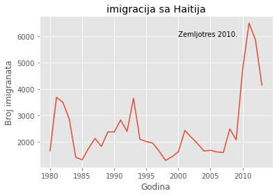

```python
haiti.index = haiti.index.map(int) # menjamo vrednost indeks vrednosti haiti dataseta u tip integer za prikaz
haiti.plot(kind='line')

#dodeljujemo naslov i nazive x i y osama
plt.title('imigracija sa Haitija')
plt.ylabel('Broj imigranata')
plt.xlabel('Godina')
# dodajemo anotaciju za zemljotres 2010 godine
plt.text(2000, 6000, 'Zemljotres 2010.')

plt.show()
```

U sledećem primeru ćemo posmatrati dve države i porediti broj migranata u datom periodu

Napravićemo novi dataframe koji će sadržati podatke o broju izbeglica iz Bosne i Hrvatske u periodu od 1980-2013.

```python
balkan = df_can.loc[['Croatia', 'Bosnia and Herzegovina'], years]
balkan.head()
```

| Country | 1980 | 1981 | 1982 | 1983 | 1984 | 1985 | 1986 | 1987 | 1988 | 1989 | ... | 2004 | 2005 | 2006 | 2007 | 2008 | 2009 | 2010 | 2011 | 2012 | 2013 |
| --- | --- | --- | --- | --- | --- | --- | --- | --- | --- | --- | --- | --- | --- | --- | --- | --- | --- | --- | --- | --- | --- |
| Croatia | 0 | 0 | 0 | 0 | 0 | 0 | 0 | 0 | 0 | 0 | ... | 151 | 128 | 102 | 102 | 131 | 92 | 91 | 135 | 112 | 125 |
| Bosnia and Herzegovina | 0 | 0 | 0 | 0 | 0 | 0 | 0 | 0 | 0 | 0 | ... | 188 | 211 | 217 | 209 | 182 | 156 | 168 | 140 | 121 | 119 |

2 rows × 34 columns

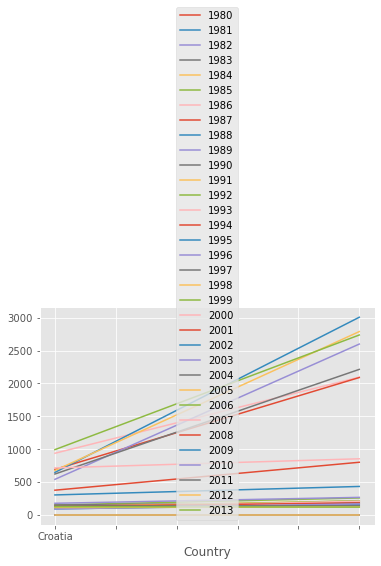

```python
balkan.plot(kind='line')
```

S obzirom da je dataframe balkan indeksiran po nazivu države, dok su datumi u kolonama, nastao je problem prilikom crtanja grafika, jer su datumi predstavljeni na y-osi kao pojedinačne linije, dok su države postavljene na x-osu.

Kako bi se ova greška ispravila, potrebno je da uradimo transpoziciju ovog dataframe-a, odnosno zamenimo kolone i redove, pozivom metode .transpose()

```python
balkan = balkan.transpose()
balkan.head()
```

| Country | Croatia | Bosnia and Herzegovina |
| --- | --- | --- |
| 1980 | 0 | 0 |
| 1981 | 0 | 0 |
| 1982 | 0 | 0 |
| 1983 | 0 | 0 |
| 1984 | 0 | 0 |

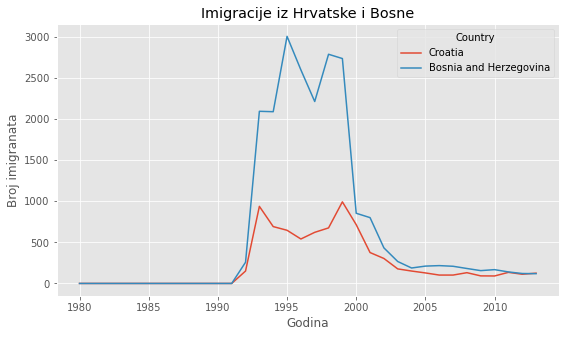

```python
balkan.index = balkan.index.map(int) #promena tipa podatka indeksa za prikaz
balkan.plot(kind='line', figsize=(9, 5)) #koristimo figsize parametar kako bismo promenili veličinu grafika

plt.title('Imigracije iz Hrvatske i Bosne')
plt.ylabel('Broj imigranata')
plt.xlabel('Godina')

plt.show()
```

Uočavamo da obe države imaju sličan trend, sa očekivanim porastom broja izbeglica tokom 90-ih godina u periodu ratnih sukoba. Ali takođe možemo primetiti da je rast broja imigranata iz Bosne tada bio značajno veći, dok su vrednosti u skorijim godinama skoro izjednačene.

```python
# napomena #
#ovaj problem se nije javio u prethodnom primeru, jer haiti, za razliku od balkan nije dataframe već serija
#što možemo proveriti pozivom sledeće funkcije
print(type(haiti))
print(type(balkan))
```

```
<class 'pandas.core.series.Series'>
<class 'pandas.core.frame.DataFrame'>
```

Line plot je odličan za prikazivanje nekoliko zavisnih promenljivih kroz jednu nezavisnu promenljivu, ali treba voditi računa da broj linija na jednom grafiku ne bude veći od 5-10 jer u suprotnom, prikaz postaje težak za interpretaciju.

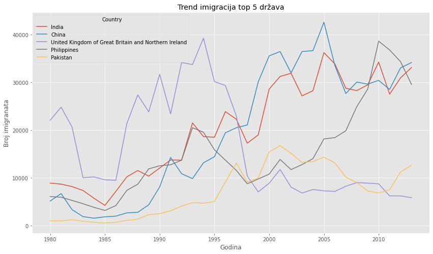

```python
df_can.sort_values(by='Total', ascending=False, axis=0, inplace=True) #inplace = True parametar čuva promene na originalnom df_can dataframeu

# uzimamo 5 država sa najvećim ukupnim brojem migranata
df_top5 = df_can.head(5)

    # transpozicija dataframe-a i promena tipa podatka indeksa
df_top5 = df_top5[years].transpose()
df_top5.index = df_top5.index.map(int)


df_top5.plot(kind='line', figsize=(14, 8))


plt.title('Trend imigracija top 5 država')
plt.ylabel('Broj imigranata')
plt.xlabel('Godina')

plt.show()
```

## Matplotlib

Jedna je od najkorišćenijih biblioteka za vizualizaciju podataka u Pythonu.Kreirana je od strane *Johna Huntera*, neurobiologa koji je u okviru svog istraživačkog tima analizirao elektrokortikografske, ECoG signale. Za to su koristili poseban softver baziran, za koji su samo jednu licencu. Zbog toga je želeo da taj softver zameni verzijom koja je bazirana na MATLAB-u koji bi mogli koristiti svi članovi tima.

Matplotlib je dakle originalno razvijen kao alat za vizalizaciju podataka sa ECoG/EEG. Kao i MATLAB, rezultujući softver je imao scripting interfejs za lako i jednostavno generisanje grafova pomoću pyplota.

Matplotlib sadrži veliki broj funkcija koje se mogu koristiti za različite tipove vizuelizacije. U narednom delu sledi obih arhitekture biblioteke, osnove korišćenja kao i neki od najkorišćenijih plotova.

### Arhitektura Matplotib biblioteke

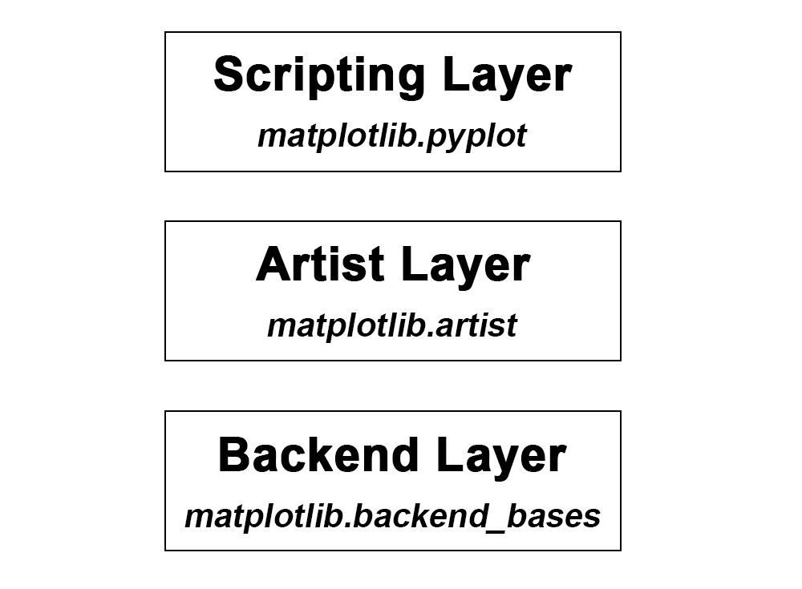

**Backend Layer** ima tri ugrađena apstraktna interfejsa:

1. *FigureCanvas*, koji definiše prostor na kome se grafik iscrtava
2. *Renderer*, čija instanca zna kako da iscrtava na FigureCanvas-u
3. *Event*, koji upravlja ulazima korisnika poput klika na tastaturi ili mišu.

**Artist Layer** ima jedan glavni objekat, i to je *Artist*. Ovaj objekat zna kako da kako da koristi Renderer-a i iscrtava "mastilom" po "platnu" (canvas). Sve vidljivo na Matplotlib figure je zapravo instanca artista. Naslov, linije, tikovi, slike odgovorajau pojedinačnim artistima.

Postoje dva tipa Artist objekata. Prvi je primitivni, poput linije, pravougaonika, teksta ili kruga. Drugi tip je složeni, kompozitni, poput figure i osa(Axes), koje su zapravo i najbitniji složeni artisti jer se tu većina Maplotlib API plotting metoda definišu, poput onih za kreiranje i upravljanje tikovima, linijama osa, mrežom (grid) ili pozadinom grafika.

Složeni artisti takože mogu sadržati druge *primitivne* ili *složene* artiste.

**Scripting Layer** je kreiran za naučnike koji nisu programeri. Ovaj nivo je u suštini Matplotlib.pyplot interfejs, koji automatizuje proces definisanja canvasa i instance figure artista i njihovog povezivanja.

Razlika između ova dva pristupa demonstrirana je u kodu ispod.

```python
# Importovanje FigureCanvas iz backenda po izboru
#  na njega "prikačiti" Figure artist
from matplotlib.backends.backend_agg import FigureCanvasAgg as FigureCanvas
from matplotlib.figure import Figure
fig = Figure()
canvas = FigureCanvas(fig)

# Importovanje numpy biblioteke da bismo generisani slučajne brojeve.
import numpy as np
x = np.random.randn(10000)
#Sada koristimo figure metodu da bismo kreairaliAxes artist;
#  On je automatski dodan na figure container fig.axes.
#  "111" dolazi iz MATLAB-ove konvencije: kreiraj mrežu sa jednim redom i jednom kolonom
#  I koristi prvu ćeliju za lokaciju za Axes.
ax = fig.add_subplot(111)

# Pozovi Axes metodu hist za generisanje histograma; hist kreira
#  sekvencu, niz Pravougaonih artists za svaki bar histograma i dodaje ih u
#Axes container. 100 označava da želimo da se kreiramo 100 binova.
ax.hist(x, 100)

# Dekoracija figure sa naslovom i potom je čuvamo.
ax.set_title('Normalna raspodela sa $\mu=0, \sigma=1$')
fig.savefig('matplotlib_histogram.png')
```

Ovo je rezultat gornjeg koda:

[figure not shown]

Sada prikazujemo kako bi to izgledalo korišćenjem pyplot interfejsa:

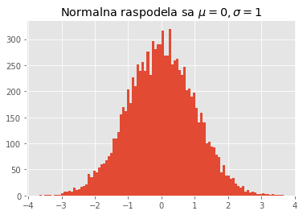

```python
import matplotlib.pyplot as plt
import numpy as np

x = np.random.randn(10000)
plt.hist(x, 100)
plt.title(r'Normalna raspodela sa $\mu=0, \sigma=1$')
plt.savefig('matplotlib_histogram.png')
plt.show()
```

### Iscrtavanje osnovnih grafika

Prva stvar koju je potrebno uraditi kako bi se radilo sa Matplotlib bibliotekom je njen import, i koristimo alijas mpl. Pored toga, proveravamo i verziju paketa:

```python
import matplotlib as mpl
print('Matplotlib verzija: '+mpl.__version__)
```

```
Matplotlib verzija: 3.3.2
```

Moć Scripting Interfejsa je u mogućnosti da se praktično skoro svi tipovi grafika, poput histograma, bar chartova, box plotova i mnogih drugih mogu kreirati samo jednom funkcijom: plot. Sada imortujemo Scripting interfejs, po konvenciji sa alijasom plt, zatim iscrtavamo prosti grafik:

```python
%matplotlib inline
#koristimo inline backend da bismo primorali da se grafik otvori u ovom prozoru pretraživača
import matplotlib.pyplot as plt
```

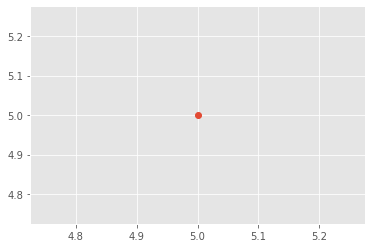

```python
plt.plot(5,5,'o')
plt.show()
```

Ovaj grafik se nakon renderovanja, ne može izmeniti.Ukoliko bismo želeli da dodamo nazive osa ili naslov, morali bismo da kreiramo novi krafik i to pre poziva *show()* funkcije. Da bismo to oprevazišli možemo koristiti *notebook* backend koji bi prethodno proverio da li postoji figure, i sve izmene bi se izvršilo nad njom, a u suprotnom kreirao bi se novi grafik.

Pandas takođe ima ugrađenu implementaciju za Matplotlib, pa je iscrtavanje grafika veoma jednostavno nad pandas serijama ili dataframe-ovima i može se izvršiti funkcijom *plot()*.

### Line plot

Line plot je tip plota koji prikazuje informacije kao serije tačaka koje se nazivaju "markeri" koje su povezane segmentima pravih linija. Veoma je često korišćen, i van polja Data Science-a, i prigodan je za prilike kada imamo kontinualne podatke, i prikazujemo podatke kroz neki vremenski period.

O njemu je već bilo govora, te ćemo nastaviti sa drugim plotovima.

### Area Plot

Još se naziva i Area chart ili graph. Najčešće se koristi kako bi se prikazale akulumirane brojčane ili procentualne vrednosti kroz neki vremenski period. Baziran je na line plotu i i često se koristi kada je potrebno uporediti dve ili više vrednosti. Do sada smo kreirali linijski plot koji je prikazivao top 5 zemalja koje najviše doprinose imiigraciji u Kanadu u periodu od 1980-2013. Sa malom izmenom koda, sada možemo nacrtati i kumulativni plot- **Stacked Line Plot** tj. **Area plot**.

```python
df_can.sort_values(['Total'], ascending=False, axis=0, inplace=True)

# uzimanje 5 redova
df_top5 = df_can.head()

# transponovanje dataframe-a
df_top5 = df_top5[years].transpose()

df_top5.head()
```

| Country | India | China | United Kingdom of Great Britain and Northern Ireland | Philippines | Pakistan |
| --- | --- | --- | --- | --- | --- |
| 1980 | 8880 | 5123 | 22045 | 6051 | 978 |
| 1981 | 8670 | 6682 | 24796 | 5921 | 972 |
| 1982 | 8147 | 3308 | 20620 | 5249 | 1201 |
| 1983 | 7338 | 1863 | 10015 | 4562 | 900 |
| 1984 | 5704 | 1527 | 10170 | 3801 | 668 |

Area plots su, ukoliko se ne naglasi drugačije, naslagani jedan na drugi. Kako bi to bilo izvodljivo, svaka kolona mora imati vrednosti koje su ili sve pozitivne ili sve negativne (*NaN* vrednosti će postati nule). Da graf ne bi bio naslagan, treba proslediti `stacked=False`. To ćemo prikazati u primerima koji slede.

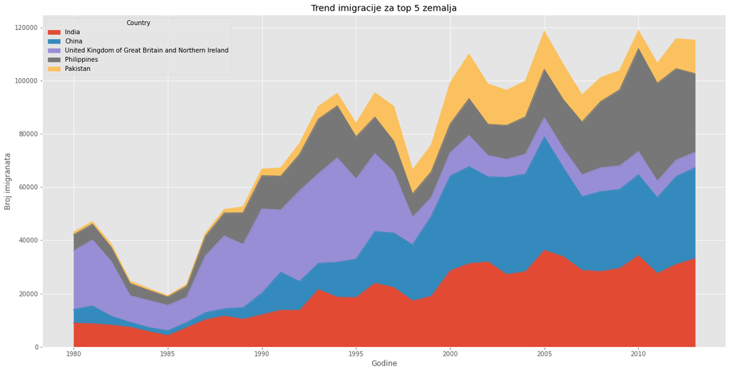

```python
df_top5.index = df_top5.index.map(int) # let's change the index values of df_top5 to type integer for plotting
df_top5.plot(kind='area', figsize=(20,10))

plt.title('Trend imigracije za top 5 zemalja')
plt.ylabel('Broj imigranata')
plt.xlabel('Godine')

plt.show()
```

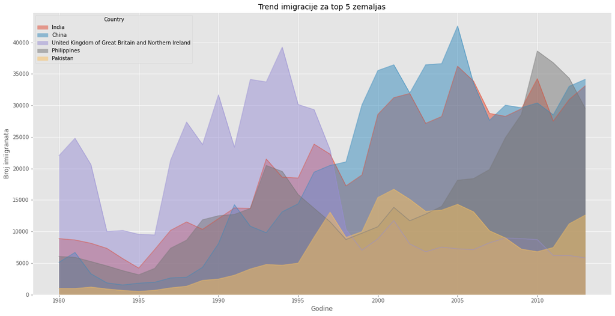

```python
df_top5.index = df_top5.index.map(int)
df_top5.plot(kind='area',
             stacked=False,
             figsize=(20, 10),
             )

plt.title('Trend imigracije za top 5 zemaljas')
plt.ylabel('Broj imiigranata')
plt.xlabel('Godine')

plt.show()
```

Nenaslagani plot ima predefinisanu alfa vrenost (transparentnost) na 0.5. Nju možemo promeniti prosleđivanjem parametra `alpha`. Što je vrednost bliža nuli, graf je providniji.

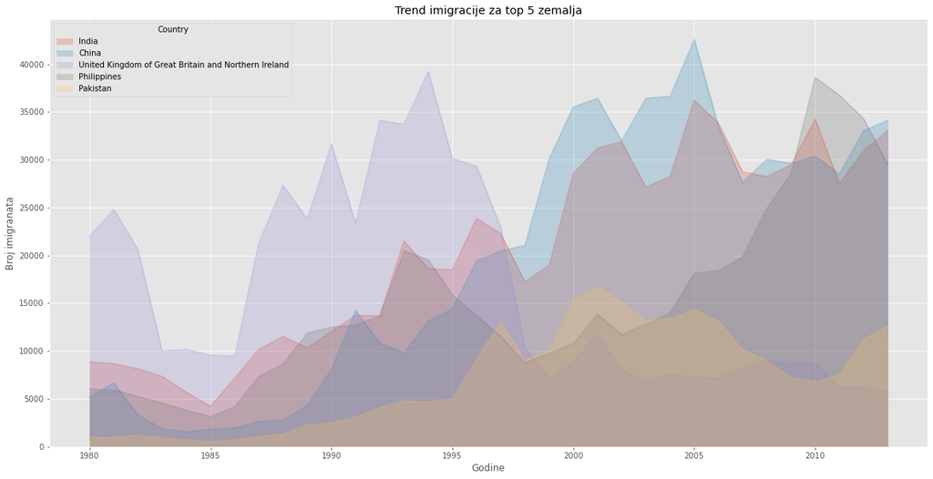

```python
df_top5.plot(kind='area',
             alpha=0.25, # 0-1, default value a= 0.5
             stacked=False,
             figsize=(20, 10),
            )

plt.title('Trend imigracije za top 5 zemalja')
plt.ylabel('Broj imigranata')
plt.xlabel('Godine')

plt.show()
```

Kao što smo već istakli, moguća su dva metoda iscrtavanja pomoću `matplotlib` biblioteke- koristeći Artist layer i scripting layer.

**Opcija 1: Scripting layer(proceduralni metod)- koristeći matplotlib.pyplot as 'plt'**

Sada se `plt` tj. `matplotlib.pyplot` može koristiti za dodavanje novih elemenata pozivom drugih metoda, proceduralno, poput `plt.title(...)` za dodavanje naslova ili `plt.xlabel(...)` za dodavanje labele x-osi.

```
df_top5.plot(kind='area', alpha=0.35, figsize=(20, 10))
    plt.title('Trend imigracije za top 5 zemalja')
    plt.ylabel('Broj imigranata')
    plt.xlabel('Godine')
```

**Opcija 2: Artist layer (Objektno orijentisani metod) - korišćenje `Axes` instance iz Matplotliba**

`Axes` instanca tekućeg plota se pože sačuvati u nekoj promenljivoj (npr. `ax`). Može se dodavati još elemenata pozivom metoda uz manju izmenu u sintaksi (dodavajući "_set__" prethodnim metodama). Na primer, koristi se `ax.set_title()` umesto `plt.title()` za dodavanje naslova, ili `ax.set_xlabel()`umesto `plt.xlabel()` za dodavanje labele x-osi.

Ova opcija, iako malo rogobatna, može biti korisna kada su u pitanju naprednije vizualizacije podataka.

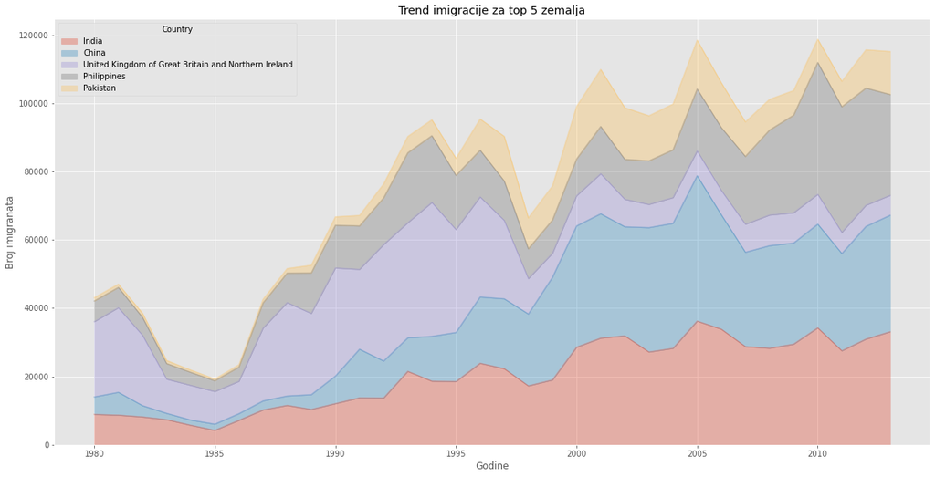

```python
#Opcija 2 sa više fleksibilnosti
ax = df_top5.plot(kind='area', alpha=0.35, figsize=(20, 10))

ax.set_title('Trend imigracije za top 5 zemalja')
ax.set_ylabel('Broj imigranata')
ax.set_xlabel('Godine')
```

Vidimo ogroman udeo imigraciju iz Indije i Kine u Kanadu. Pored toga što je sama Kanada otvorena za imigraciju, ove zemlje su verovatno na poziciju na kojoj jesu prvo zbog brojnosti svojih nacija, te stoga postoji veći potencijalni broj ljudi koji bi emigrirali. Sa druge strane, verovatno ih siromaštvo, socioekonomski i politički razlozi kao i prilike za posao dodatno insentivizuju da promene svoje mesto boravišta. Ovo bi se moglo dublje istražiti kada bismo na primer imali uvid u starosnu strukturu i nivo obrazovanja migranata.

Prisustvo Velike Britanije na ovom spisku se može delimično objasniti dobrom saradnjom ove dve zemlje, pošto je Kanada članica Commonwealth-a i kao takva priznaje Kraljicu Elizabetu kao neku vrstu uticaja.

Sada ćemo nacrtati plot za pet zemalja iz kojih se za Kanadu najmanje emigrira.

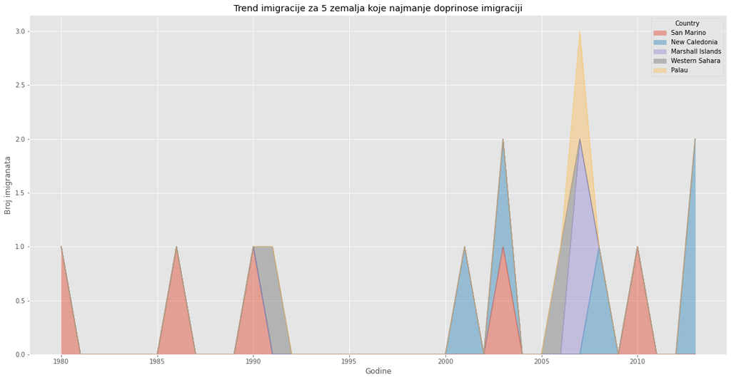

```python
df_least5 = df_can.tail(5)
df_least5 = df_least5[years].transpose()
df_least5.head()
df_least5.index = df_least5.index.map(int)
df_least5.plot(kind='area', alpha=0.45, figsize=(20, 10))
plt.title('Trend imigracije za 5 zemalja koje najmanje doprinose imigraciji')
plt.ylabel('Broj imigranata')
plt.xlabel('Godine')

plt.show()
```

Ono što odmah možemo da učiomo da je red veličine jedna osoba, te je migracija iz ovih zemalja zaista mala. Drugo, vidimo da su u pitanju takođe veoma male države sa malim brojem stanovnika te nema mnogo ko i da emigrira. Treće potencijalno objašnjenje je, što su ovo mahom ostrvske zemlje i zemlje iz predela gde je klima tropska, možda je njima Kanada neprivlačna usled kontrasta prirodnih uslova sa kojima bi se susreli.

### Histogram

Histogram je način prikazivanja raspodele frekvencija neke promenljive. Deli raspon numeričke promenljive u binove, dodeli svakom datapointu jedan bin, i zatim računa broj datapointa u svakom od binova. Ako u nekom binu ne postoji data point, njegova visina će biti nula. Funkcija je zadata ovako:

```
matplotlib.pyplot.hist(x, bins=None, range=None, density=None, weights=None, cumulative=False, bottom=None, histtype='bar', align='mid', orientation='vertical', rwidth=None, log=False, color=None, label=None, stacked=False, normed=None, *, data=None, **kwargs)
```

**Pitanje:** Koja je raspodela frekvencija broja (populacije) novih migranata iz različitih zemalja u Kanadu u 2013 godini?

Pre iscrtavanja samog histograma, prvo proveravamo kako izgledaju podaci kada se podele u intervale.Za to koristimo `histrogram` metodu iz **Numpy**-ja da bismo dobili opsege binova i frekvencije. Prvo ćemo se podsetiti kako izgledaju naši podaci, zatim iskoristiti pomenutu metodu. Ona vraća dve vrednosti, vrednosti frekvencija i vrednosti za binove.

```python
df_can['2013'].head()
```

```
Country
India                                                   33087
China                                                   34129
United Kingdom of Great Britain and Northern Ireland     5827
Philippines                                             29544
Pakistan                                                12603
Name: 2013, dtype: int64
```

```python
count, bin_edges = np.histogram(df_can['2013'])
```

Predefinisano `histrogram` metoda deli naš dataset na 10 binova. Slika ispod sumira vrednosti za binove i njihove fekvencijeza imigraciju u 2013. Vidimo da je te godine:

- 178 zemlja imala između 0 i 3412.9 imigranata
- 11 zemalja imala između 3412.9 i 6825.8 imigranata
- 1 zemlja imala između 6285.8 i 10238.7 imigranata, i tako dalje...

[figure not shown]

Ovu raspodeluju frekvencija jednostavno možemo nacrtati koristeći `kind=hist`u okviru `plot()` funkcije.

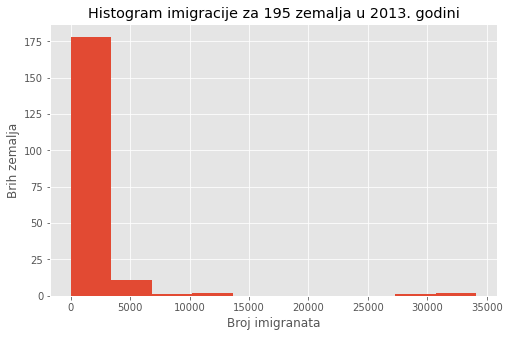

```python
df_can['2013'].plot(kind='hist', figsize=(8, 5))

plt.title('Histogram imigracije za 195 zemalja u 2013. godini') # dodavanje naslova histogramu
plt.ylabel('Brih zemalja') # dodavanje y-labele
plt.xlabel('Broj imigranata') # dodavanje x-labele

plt.show()
```

Na gornjem plotu, x osa predstavlja raspon populacije imigranaata u intervalima od 3412.9. Y- osa predstavlja broj zemalja koje su doprinele imigraciji za svaku od grupa. Primećujemo da labele na x-osi ne odgovaraju širini jednog bina. Zato proslećujemo ključnu reč `xticks` koja u sebi sadrži listu veličina binova:

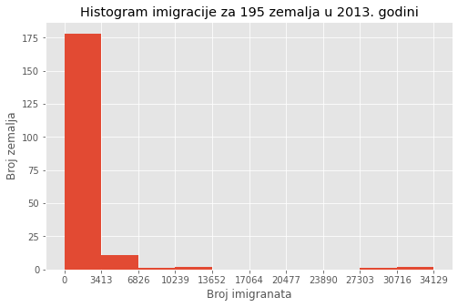

```python
count, bin_edges = np.histogram(df_can['2013'])

df_can['2013'].plot(kind='hist', figsize=(8, 5), xticks=bin_edges)

plt.title('Histogram imigracije za 195 zemalja u 2013. godini') # dodavanje naslova histogramu
plt.ylabel('Broj zemalja') # dodavanje y-labele
plt.xlabel('Broj imigranata') # dodavanje x-labele

plt.show()
```

*Side Note:* Moglo se koristiti i`df_can['2013'].plot.hist()`. Više o tome postoji u *pandas* dokumentaciji. http://pandas.pydata.org/pandas-docs/stable/generated/pandas.Series.plot.html.

Možemo crtati nekoliko histograma na jednom plotu.Demonstriraćemo to na sledećem primeru:

Ako ne želimo da se plotovi međusobno preklapaju, možemo proslediti i `stacked` parametar. Prilagodićemo i labele za x i y ose da bismo otklonili praznine sa leve i desne strane samog plota.Za to prosleđujemo tuple(min,max) koristeći `xlim` parametar.

```python
#transponovanje dataseta
df_t = df_can.loc[['Denmark', 'Norway', 'Sweden'], years].transpose()
df_t.head()
```

| Country | Denmark | Norway | Sweden |
| --- | --- | --- | --- |
| 1980 | 272 | 116 | 281 |
| 1981 | 293 | 77 | 308 |
| 1982 | 299 | 106 | 222 |
| 1983 | 106 | 51 | 176 |
| 1984 | 93 | 31 | 128 |

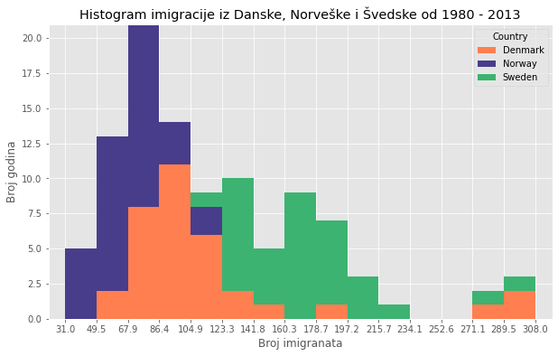

```python
count, bin_edges = np.histogram(df_t, 15)
xmin = bin_edges[0] - 10   #  iz istetskih razloga dodajemo male praznine levo i desno
xmax = bin_edges[-1] + 10

# stacked Histogram
df_t.plot(kind='hist',
          figsize=(10, 6),
          bins=15,
          xticks=bin_edges,
          color=['coral', 'darkslateblue', 'mediumseagreen'],
          stacked=True,
          xlim=(xmin, xmax)
         )

plt.title('Histogram imigracije iz Danske, Norveške i Švedske od 1980 - 2013')
plt.ylabel('Broj godina')
plt.xlabel('Broj imigranata')

plt.show()
```

Vidimo da u nižim delovima grafa, tj. gde je manji broj imigranata, dominira Norveška, dok sa većim brojem imigranata ima Danaca i Šveđana. Generalno ova distribucija je nagnuta na levo i nema toliko ljudi koji su radi da napuste svoje tople skandinavske domove.

### Bar Chart

Takođe jedan od veoma često korišćenih alata. Za razliku od histograma, Bar Chart je često korišćen za poređenje vrednosti promenljive u nekom konkretnom trenutku. Bar Chart ili Graph je tip plota na kome je dužina svakog bara proporcionalna vrednosti koju predstavlja. Prigodni su kako za nominalne (demografske) podatke tako i za ordinalne (sa rangom).

Čitljivost je najveća ukoliko se barovi urede npr. u opadajućem redosledu koristeći nominalne podatke. Kada su u pitanju ordinalni podaci, treba se držati redosleda kategorija bez obzira na to koja je najčešća.

Funkcija je zadata na ovakav način:

```
matplotlib.pyplot.bar(x, height, width=0.8, bottom=None, *, align='center', data=None, **kwargs)
```

Za kreiranje Bar Plotova možemo proslediti dve vrednosti za `kind` parametar u f-ji `plot()`:

- `kind=bar` kreira *vertikalni* bar plot
- `kind=barh` kreira *horizontalni* bar plot

**Vertikalni bar plot** Ovde se x-osa koristi za označavanje, i dužina barova na y-osi odgovara veličini posmatrane varijable. Veoma su korisni za posmatranje podataka vremenskih serija. Nedostatak je manjak prostora za tekstualne oznake o donjem delu svakog bara.

**Sada ćemo se pozabaviti posledicama finansijske krize koju je imao Island.** U pitanju je bitna politička tačka u istoriji zemlje. U odnosu na veličinu svoje ekonomije, slom bankarskog sistema je najveći u poređenju sa bilo kojom zemljom u istoriji ekonomije. Kriza je dovela do ozbiljne ekonomske depresije u periodu 2008-2011 i značajnim političkim nemirom. Sada ćemo, opremljeni ovom informacijom, pogledati i imigraciju za Kanadu od strane Islanda u periodu od 1980-2013.

Ovo ćemo anotirati na plotu koristeći `annotate` metodu iz **scripting layer**-a ili **pyplot interface**-a. Prosleđujemo sledeće parametre:

- `s`: str, tekst za anotaciju
- `xy`: Tuple koji označava tačku za anotaciju- krajnu tačku strelice.
- `xytext`: Tuple koji označava tačku (x,y)za postavljanje teksta- početak strelice
- `xycoords`: Koordinatni sistem u kom je xy dat.
- `arrowprops`:Prihvata rečkih propertija da isrcta strelicu:
  - `arrowstyle`: Specificira stil strelice, `'->'` je standardna.
  - `connectionstyle`: Specificira tip konekcije. `arc3` je prava linija
  - `color`: Specificiranje boje strelice
  - `lw`: Specificira debljinu linije.

Takođe ćemo anotirati i tekst koji ide iznad strelice.

- `rotation`: rotacioni ugao u smeru suprotnom od kazaljke na satu, dat u stepenima
- `va`: vertikalno poravnanje teksta [‘center’ | ‘top’ | ‘bottom’ | ‘baseline’]
- `ha`: horizontalno poravnanje teksta [‘center’ | ‘right’ | ‘left’]

```python
# korak 1: odabir zemlje:
df_iceland = df_can.loc['Iceland', years]
df_iceland.head()
```

```
1980    17
1981    33
1982    10
1983     9
1984    13
Name: Iceland, dtype: object
```

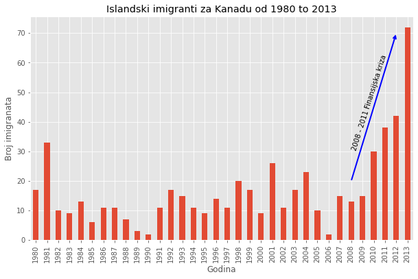

```python
df_iceland.plot(kind='bar', figsize=(10, 6), rot=90)

plt.xlabel('Godina')
plt.ylabel('Broj imigranata')
plt.title('Islandski imigranti za Kanadu od 1980 to 2013')

# Annotate arrow
plt.annotate('',                      # bez teksta
             xy=(32, 70),             # vrh strelice na tačku (year 2012 , pop 70)
             xytext=(28, 20),         # osnova strelice na tačku (year 2008 , pop 20)
             xycoords='data',         # koristiće koordinatni sitem anotiranog objekta
             arrowprops=dict(arrowstyle='->', connectionstyle='arc3', color='blue', lw=2)
            )

# Annotate Text
plt.annotate('2008 - 2011 Finansijska kriza', # Tekst za prikaz
             xy=(28, 30),                    # Početak teksta u tački (year 2008 , pop 30)
             rotation=72.5,                  # isprobavanjem se došlo do ovog ugla
             va='bottom',                    # vertikalno poravnanje po dnu
             ha='left',                      # horizontalno poravnanje sa leve strane
            )

plt.show()
```

Vidimo da je naše poznavanje ekonomije doprinese razumevanju podataka koje postramo.Uširem smislu, zato je korisno poznavanje oblasti čije podatke istražujemo, jer lakše uviđamo razloge i uzročno- posledične veze i zakonitosti u podacima. Ali i čak i da to nije slučaj, ukoliko smo dovoljno pažljivi da uvidimo neke neočekivane promene, uz malo istraživanja rasvetlićemo sebi i drugima zašto je situacija takva kakva jeste.

**Horizontal Bar Plot** Ponekad je praktičnije prikazati podatke horizontalno, pogotovo ako nam je potrebno više prostora za označavanje barova. U ovom slučaju, y-osa je za označavanje, a dužina barova na x-osi odgovara veličini promeljive koja se koristi. Sada na y-osi ima više prostora za označavanje kategorijskih promenljivih.

**Zadatak:** Kreirati *horizontalni* bar plot koji prikazuje *ukupan* broj imigranata u Kanadu iz top 15 zemalja, u periodu od 1980 - 2013. Označiti svaku zemlju po ukupnom broju migranata.

```python
# sortiranje data frejma po koloni 'Total' u opadajućem redosledu
df_can.sort_values(by='Total', ascending=True, inplace=True)
df_top15 = df_can['Total'].tail(15)
df_top15
```

```
Country
Romania                                                  93585
Viet Nam                                                 97146
Jamaica                                                 106431
France                                                  109091
Lebanon                                                 115359
Poland                                                  139241
Republic of Korea                                       142581
Sri Lanka                                               148358
Iran (Islamic Republic of)                              175923
United States of America                                241122
Pakistan                                                241600
Philippines                                             511391
United Kingdom of Great Britain and Northern Ireland    551500
China                                                   659962
India                                                   691904
Name: Total, dtype: int64
```

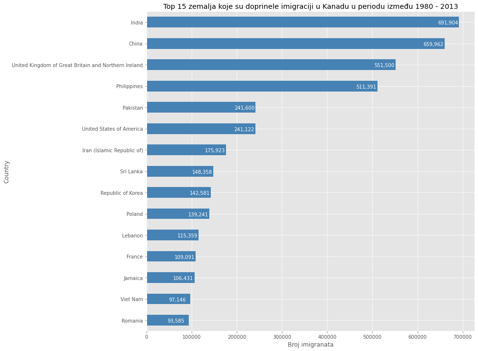

```python
df_top15.plot(kind='barh', figsize=(12, 12), color='steelblue')
plt.xlabel('Broj imigranata')
plt.title('Top 15 zemalja koje su doprinele imigraciji u Kanadu u periodu između 1980 - 2013')

# anotiranje labela za svaku zemlju
for index, value in enumerate(df_top15):
    label = format(int(value), ',') # format int with commas

    # postavljanje teksta na kraj bara (oduzimanje kako bi stalo u bar)
    plt.annotate(label, xy=(value - 47000, index - 0.10), color='white')

plt.show()
```

### Pie Chart

Ovo je kružni statistički grafik podeljen na parčiće(*slices*) kako bi prikazao proporcije deljenjem kruga. Postoje zagovornici protiv bilo kakvog korišćenja ovog grafika, zauzimajući stav da ne pokazuje konzistentno podatke, i ta je za tako nešto bolje koristiti Bar Charts jer se na njemu bolje vide trendovi i paterni promene. Dodatno, 3D verzije mogu drastično da iskrive podatke, čineći da dva dela koji su veoma različiti deluju da su skoro iste veličine.

Ima svoju cenjeniju verziju u *Donut plot*-u, koji je takođe u plt.pie funkciji.

Funkcija je definisana ovako:

```
matplotlib.pyplot.pie(x, explode=None, labels=None, colors=None, autopct=None, pctdistance=0.6, shadow=False, labeldistance=1.1, startangle=None, radius=None, counterclock=True, wedgeprops=None, textprops=None, center=(0, 0), frame=False, rotatelabels=False, *, data=None)
```

Možemo ih kreirati u Matplotlib prosleđivanjem `kind=pie` ključne reči. Korak 1: Prikupljanje podataka.

Koristićemo *pandas* `groupby` metodu za sumranje podataka o imigraciji po polju `Continent`. Opšti proces za `groupby` uključuje sledeće korake:

1. **Split:** Deljenje podataka u grupe po nekom kriterijumu
2. **Apply:** Primena funkcije na svaku grupu pojedinačno: .sum() .count() .mean() .std() .aggregate() .apply() .etc..
3. **Combine:** Kombinovanje rezultata u neku strukturu podataka.

[figure not shown]

```python
# grupiše zemlje o kontinentu i primenljuje funkciju sum()
df_continents = df_can.groupby('Continent', axis=0).sum()

# note:izlaz iz groupby() metode je groupby objekat
# ne možemo ga koristiti ukoliko ne primenimu funkciju npr sum()
print(type(df_can.groupby('Continent', axis=0)))
df_continents.head()
```

```
<class 'pandas.core.groupby.generic.DataFrameGroupBy'>
```

| Continent | 1980 | 1981 | 1982 | 1983 | 1984 | 1985 | 1986 | 1987 | 1988 | 1989 | ... | 2005 | 2006 | 2007 | 2008 | 2009 | 2010 | 2011 | 2012 | 2013 | Total |
| --- | --- | --- | --- | --- | --- | --- | --- | --- | --- | --- | --- | --- | --- | --- | --- | --- | --- | --- | --- | --- | --- |
| Africa | 3951 | 4363 | 3819 | 2671 | 2639 | 2650 | 3782 | 7494 | 7552 | 9894 | ... | 27523 | 29188 | 28284 | 29890 | 34534 | 40892 | 35441 | 38083 | 38543 | 618948 |
| Asia | 31025 | 34314 | 30214 | 24696 | 27274 | 23850 | 28739 | 43203 | 47454 | 60256 | ... | 159253 | 149054 | 133459 | 139894 | 141434 | 163845 | 146894 | 152218 | 155075 | 3317794 |
| Europe | 39760 | 44802 | 42720 | 24638 | 22287 | 20844 | 24370 | 46698 | 54726 | 60893 | ... | 35955 | 33053 | 33495 | 34692 | 35078 | 33425 | 26778 | 29177 | 28691 | 1410947 |
| Latin America and the Caribbean | 13081 | 15215 | 16769 | 15427 | 13678 | 15171 | 21179 | 28471 | 21924 | 25060 | ... | 24747 | 24676 | 26011 | 26547 | 26867 | 28818 | 27856 | 27173 | 24950 | 765148 |
| Northern America | 9378 | 10030 | 9074 | 7100 | 6661 | 6543 | 7074 | 7705 | 6469 | 6790 | ... | 8394 | 9613 | 9463 | 10190 | 8995 | 8142 | 7677 | 7892 | 8503 | 241142 |

5 rows × 35 columns

Korak 2: Iscrtavanje podataka. Pored `kind = 'pie'` ključne reči,prosleđujemo dodatne parametre:

- `autopct` - string ili funkcija za označavanje "klinova" njihovim numeričkim vrednostima i biće smeštena u njega. Ako je string, labela će biti `fmt%pct`.
- `startangle` - rotira početak Pita grafika za neki ugao u stepenima od x-ose u smeru suprotnom od kazaljke na satu.
- `shadow` - iscrtava senku ispod pite da bi mu dodala 3D efekat.

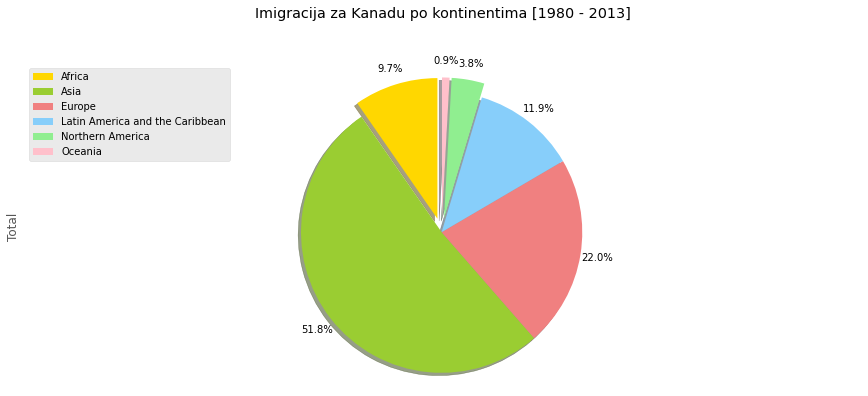

```python
colors_list = ['gold', 'yellowgreen', 'lightcoral', 'lightskyblue', 'lightgreen', 'pink']
explode_list = [0.1, 0, 0, 0, 0.1, 0.1] # odnos za svaki kontinent kojim se offsetuje svaki slice.

df_continents['Total'].plot(kind='pie',
                            figsize=(15, 6),
                            autopct='%1.1f%%',
                            startangle=90,
                            shadow=True,
                            labels=None,         # isključivanje labeli
                            pctdistance=1.12,    # odnos centara svakog dela pite i početak teksta generisan od strane autopct
                            colors=colors_list,  # dodavanje boja
                            explode=explode_list # 'explode' tri najmanja kontinenta
                            )

# Skaliranje naslova, povećanje za 12% da odgovara pctdistance
plt.title('Imigracija za Kanadu po kontinentima [1980 - 2013]', y=1.12)

plt.axis('equal')

# dodavanje legende
plt.legend(labels=df_continents.index, loc='upper left')

plt.show()
```

Vidimo da je više od 50% migracija iz Azije, što odgovara našim prethodnim saznanjima, jer su Kina, Indija, Filipini i Pakistan među 5 najvećih imigrata u Kanadu a to su sve države u Aziji, sa veoma velikom populacijom. 22% njih dolazi iz Evrope, i ovaj procenat verovatno u velikoj meri vuče Velika Britanija s obirom da je i ona u top 5 zemalja. Ovde vidimo odnose, ali ne vidimo o kakvim brojevima je reč, te stoga iako je često korišćeni grafik, postoje mnogi drugi koji u sebi sadrže veću količinu informacija.

### Box Plot

`Box Plotovi` su način za statističko prikazivanje distribucije datih podataka kroz pet osnovnih dimenzija:

- **Minimum**, koji je najmanja vrednost među sortiranim podacima. Njegova vrednost se dobija oduzimanjem 1.5*IQR (*Interquantile range*) od prvog kvartila.
- **Prvi kvartil** koji je na 25% sortiranih podataka. To znači da je 1/4 datapointa manja od ove vrednosti.
- **Medijana** sortiranih vrednosti.
- **Treći kvartil**, koji se nalazi na 75% podataka. To znači da 3/4 naših datapointa imaju vrednost koja je manja od ove.
- **Maksimum**, koji je najveća vrednost među sortiranim podacima, koji je vrednost trećeg kvartila sabranim sa 1.5*IQR.

Van ovih granica, nalaze se outlieri u vidu pojedinačnih tačaka

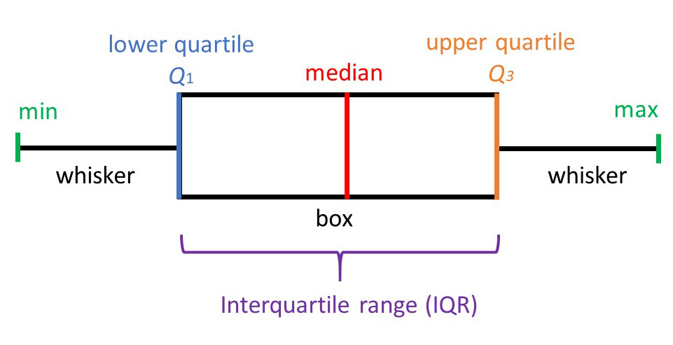

Sama funkcija specificirana je na sledeći način:

```
matplotlib.pyplot.boxplot(x, notch=None, sym=None, vert=None, whis=None, positions=None, widths=None, patch_artist=None, bootstrap=None, usermedians=None, conf_intervals=None, meanline=None, showmeans=None, showcaps=None, showbox=None, showfliers=None, boxprops=None, labels=None, flierprops=None, medianprops=None, meanprops=None, capprops=None, whiskerprops=None, manage_ticks=True, autorange=False, zorder=None, *, data=None)
```

Za iscrtavanje, možemo koristiti `kind=box` u `plot` metodi pozvanoj nad *pandas* serijom ili dataframe-om. Iscrtaćemo box plot za Japanske imigrante u periodu od 1980-2013

Korak 1: Uzimanje dataseta. Iako uzimamo podatke samo za jednu zemlju, uzećemo je kao dataframe. Ovo će nam omogućiti da pozovemo metodu `dataframe.describe()`i prikažemo percentile. Korak 2: Plot by passing in `kind='box'`.

```python
# Za uzimanje dataframe-a, postaviti još jedan par zagrada oko Japana.
df_japan = df_can.loc[['Japan'], years].transpose()
df_japan.head()
```

| Country | Japan |
| --- | --- |
| 1980 | 701 |
| 1981 | 756 |
| 1982 | 598 |
| 1983 | 309 |
| 1984 | 246 |

We can view the actual numbers by calling the `describe()` method on the dataframe.

```python
df_japan.describe()
```

| Country | Japan |
| --- | --- |
| count | 34.000000 |
| mean | 814.911765 |
| std | 337.219771 |
| min | 198.000000 |
| 25% | 529.000000 |
| 50% | 902.000000 |
| 75% | 1079.000000 |
| max | 1284.000000 |

```python
df_CI= df_can.loc[['China', 'India'], years].transpose()
df_CI.describe()
```

| Country | China | India |
| --- | --- | --- |
| count | 34.000000 | 34.000000 |
| mean | 19410.647059 | 20350.117647 |
| std | 13568.230790 | 10007.342579 |
| min | 1527.000000 | 4211.000000 |
| 25% | 5512.750000 | 10637.750000 |
| 50% | 19945.000000 | 20235.000000 |
| 75% | 31568.500000 | 28699.500000 |
| max | 42584.000000 | 36210.000000 |

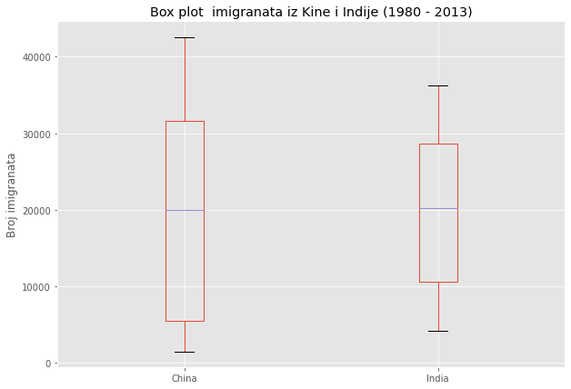

```python
df_CI.plot(kind='box', figsize=(10, 7))

plt.title('Box plot  imigranata iz Kine i Indije (1980 - 2013)')
plt.ylabel('Broj imigranata')

plt.show()
```

Vidimo da obe zemlje imaju sličnu medijanu imigrantske populacije, približno 20 000, ali Kina ima veći opseg vrednosti u odnosu na Indiju. Najveći broj za Indiju za sve godine (36210) je za oko 15% niži u odnosu na populaciju iz Kine (42584).

Ako je nekome draže da kreira horizontalne box plotove, i to je moguće ovde, prosleđivanjem `vert` parametra u **plot** funkciju i postavljanjem njega na *False*. Takođe se može specificirati i druga boja ukoliko niste ljubitelj predefinisane crvene boje.

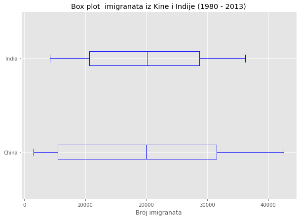

```python
df_CI.plot(kind='box', figsize=(10, 7), color='blue', vert=False)

plt.title('Box plot  imigranata iz Kine i Indije (1980 - 2013)')
plt.xlabel('Broj imigranata')

plt.show()
```

**Subplots**

Često nam zatreba više plotova u okviru jedne figure. Možda nam, na primer, treba upoređivanje box plot uz line plot imigracije za Kinu i Indiju.

Zato kreiramo **`figure`** ( canvas) i delimo u **`subplotove`**,gde svaki sadrži plot. Sa **subplotovima**, često koristimo **artist layer** umesto **scripting layer**.

Sintaksa :

```
fig = plt.figure() # kreiranje figure
    ax = fig.add_subplot(nrows, ncols, plot_number) # kreiranje subplotova
```

Gde:

- `nrows` i `ncols` dele figuru na (`nrows` * `ncols`) pod-osa,
- `plot_number` je identifikovanje određenog subplota koji ova funkcija kreira unutar svoje mreže.Prva vrednost je 1, raste po redovima i najveća vrednost je `nrows` * `ncols` kao što je prikazano dole.

[figure not shown]

Možemo dalje specificirati koji subplot se smešta gde prosleđivanjem `ax` parametra u `plot()` metodu:

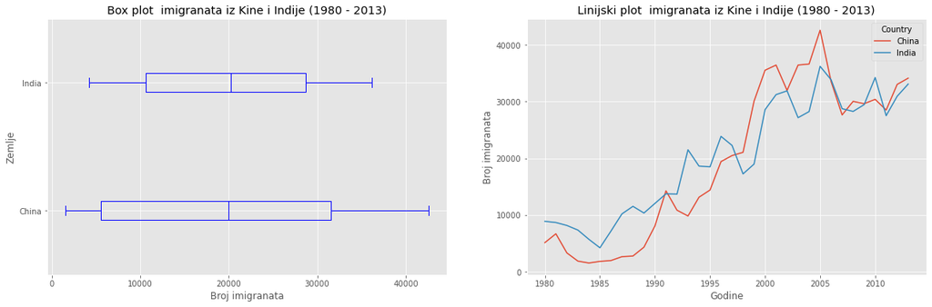

```python
fig = plt.figure() # kreiranje figure

ax0 = fig.add_subplot(1, 2, 1) # dodaje subplot 1 (1 row, 2 columns, first plot)
ax1 = fig.add_subplot(1, 2, 2) # dodaje subplot 2 (1 row, 2 columns, second plot). See tip below**

# Subplot 1: Box plot
df_CI.plot(kind='box', color='blue', vert=False, figsize=(20, 6), ax=ax0) # add to subplot 1
ax0.set_title('Box plot  imigranata iz Kine i Indije (1980 - 2013)')
ax0.set_xlabel('Broj imigranata')
ax0.set_ylabel('Zemlje')

# Subplot 2: Line plot
df_CI.plot(kind='line', figsize=(20, 6), ax=ax1) # add to subplot 2
ax1.set_title ('Linijski plot  imigranata iz Kine i Indije (1980 - 2013)')
ax1.set_ylabel('Broj imigranata')
ax1.set_xlabel('Godine')

plt.show()
```

Malo naprednije: prikazaćemo box plot za top 15 zemalja po dekadama (1980s, 1990s, 2000s).

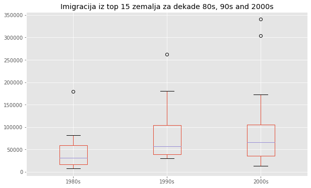

```python
df_top15 = df_can.sort_values(['Total'], ascending=False, axis=0).head(15)
    # lista godina u dekadama 80's, 90's, and 00's
years_80s = list(map(str, range(1980, 1990)))
years_90s = list(map(str, range(1990, 2000)))
years_00s = list(map(str, range(2000, 2010)))

    # deljenje originalnog  dataframe df_can za kreiranje serija po dekadama
df_80s = df_top15.loc[:, years_80s].sum(axis=1)
df_90s = df_top15.loc[:, years_90s].sum(axis=1)
df_00s = df_top15.loc[:, years_00s].sum(axis=1)

    # spajanje tri serije u jedan dataframe
new_df = pd.DataFrame({'1980s': df_80s, '1990s': df_90s, '2000s':df_00s})

    # dprikaz data frame-a
new_df.head()

new_df.describe()
new_df.plot(kind='box', figsize=(10, 6))

plt.title('Imigracija iz top 15 zemalja za dekade 80s, 90s and 2000s')

plt.show()
```

```python
new_df=new_df.reset_index()
new_df[new_df['2000s']> 209611.5]
```

|  | Country | 1980s | 1990s | 2000s |
| --- | --- | --- | --- | --- |
| 0 | India | 82154 | 180395 | 303591 |
| 1 | China | 32003 | 161528 | 340385 |

Ako gledamo 2000s kao primer:

- Q1 (25%) = 36,101.5
- Q3 (75%) = 105,505.5
- IQR = Q3 - Q1 = 69,404

Po već pomenutoj definiciji outliera:

Outlier > 105,505.5 + (1.5 * 69,404)  
Outlier > 209,611.5

Po ovome vidimo da su Kina i Indija oulieri jer njivoa populacija za dekadu prevazilazi 209,611.5.

Boxplot je napredno sredstvo za vizualizaciju. Više o njemu se može naći u Matplotlib documentaciji.

### Scatter plot

Ovaj plot prikazuje vrednosti koje se obično odnose na dve promeljive, jednu u kombinaciji sa drugom na x i y osi. Najčešće se zavisna promenljiva prikazuje u odnosu na nezavisnu kako bi se utvrdilo da li postoji nekakva korelacija između dve promenljive. Na primer, ako bismo posmatrali scatter plot prihoda naspram obrazovanja, mogli bismo da utvrdimo da li sa većim brojem godina uloženim u obrazovanje pojedinac ima veće prihode.

`Scatter plot` je sličan linijskom grafiku u smislu da oba mapiraju nezavisne i zavisne varijable na 2D grafiku. Međutim, ovde te tačke nisu povezane, i koristi se za prikazivanje trendova. Korišćenjem dublje analize korišćenjem na primer korišćenjem regresije, možemo matematički proračunati ove veze i koristiti ih da predvidimo trendove čak i van našeg dataseta.

Može biti dodata i treća promenjiva koja bi odgovarala boji ili veličini markera koja bi dodala treću dimenziju u razmatranje, za pomenuti primer to bi mogao biti pol ili stepen urbanosti sredine iz koje osoba potiče.

Funkcija izgleda ovako:

```
matplotlib.pyplot.scatter(x, y, s=None, c=None, marker=None, cmap=None, norm=None, vmin=None, vmax=None, alpha=None, linewidths=None, verts=None, edgecolors=None, *, plotnonfinite=False, data=None, **kwargs)
```

Koristeći `scatter plot`, prikazaćemo trend ukupne imigracije za Kanadu(svih zemalja zajedno) za period od 1980 - 2013.

Korak 1: Uzimanje podataka. Pošto razmatramo vezu između `years` i `total population`, konvertujemo `years`u tip `int`.

```python
# Koristimo sum() metodu da dobijemo ukupnu populaciju po godinama
df_tot = pd.DataFrame(df_can[years].sum(axis=0))

# Menjamo tip za godine pomoću map() funkcije
df_tot.index = map(int, df_tot.index)

# resetujemo index da bude ponovo kolona u df_tot dataframe-u
df_tot.reset_index(inplace = True)

# menjamo imena kolonama
df_tot.columns = ['year', 'total']

# prikaz konačnog dataframe-a
df_tot.head()
```

|  | year | total |
| --- | --- | --- |
| 0 | 1980 | 99137 |
| 1 | 1981 | 110563 |
| 2 | 1982 | 104271 |
| 3 | 1983 | 75550 |
| 4 | 1984 | 73417 |

Korak 2:Crtanje podataka pomoću `kind='scatter'` kao argument funkcije za iscrtavanje. Prosleđujemo ključne reči `x` and `y` da odaberemo kolone koje idu na x i y osu respektivno.

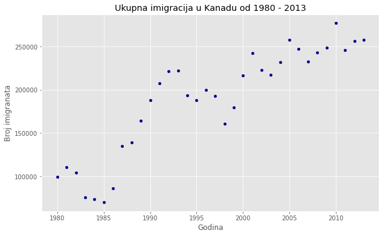

```python
df_tot.plot(kind='scatter', x='year', y='total', figsize=(10, 6), color='darkblue')

plt.title('Ukupna imigracija u Kanadu od 1980 - 2013')
plt.xlabel('Godina')
plt.ylabel('Broj imigranata')

plt.show()
```

Očigledan je rastući trend u podacima: kako godine prolaze, povećava se i ukupan broj imigranata. Kao što smo pomenuli, ovo se može koristiti i za izradu regresione krive i predviđanje vrednosti za naredne godine ili pojedinačne zemlje.

Iscrtavamo linearnu krivu koja najviše odgovara podacima, i korsitimo je da predvidimo broj imigranata u 2015.

Korak 1: Dobijanje jednačine koja će najviše odgovarati. Koristimo **Numpy**-jevu `polyfit()` metodu sa sledećim argumentima:

- `x`: x-koordinate podataka.
- `y`: y-koordinate podataka.
- `deg`:Stepen polinomijane krive 1 = linearna, 2 = kvadratna, itd.

```python
x = df_tot['year']      # godine na x-osi
y = df_tot['total']     # total na y-osi
fit = np.polyfit(x, y, deg=1)
fit
```

```
array([ 5.56709228e+03, -1.09261952e+07])
```

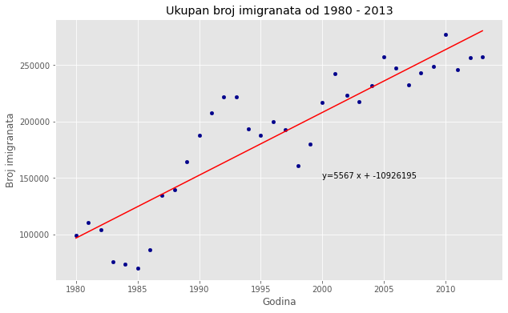

```
'Broj imigranata = 5567 * Year + -10926195'
```

```python
df_tot.plot(kind='scatter', x='year', y='total', figsize=(10, 6), color='darkblue')

plt.title('Ukupan broj imigranata od 1980 - 2013')
plt.xlabel('Godina')
plt.ylabel('Broj imigranata')

# iscrtavanje prave koja najviše odgovara
plt.plot(x, fit[0] * x + fit[1], color='red') # x- godine
plt.annotate('y={0:.0f} x + {1:.0f}'.format(fit[0], fit[1]), xy=(2000, 150000))

plt.show()

# ispis najbolje linije
'Broj imigranata = {0:.0f} * Year + {1:.0f}'.format(fit[0], fit[1])
```

Rezultat je niz sa polinomijalnim koeficijentima, poređanim od najvišeg ka najnižem stepenu. Pošto iscrtavamo linearnu regresiju, `y= a*x + b`, izlaz ima dva parametra`[5.56709228e+03, -1.09261952e+07]`

Korak 2: Iscrtavanje regresione krive na `scatter plotu`. Za procenu imigranata u 2015:

```
No. Immigrants = 5567 * Year - 10926195
No. Immigrants = 5567 * 2015 - 10926195
No. Immigrants = 291,310
```

Kada se to uporedi sa stvarnim vrednostima dobijenim od strane Citizenship and Immigration Canada (CIC) 2016 Annual Report, vidimo da je kanada prihvatila 271,845 imigranata u 2015. godini. Naša vrednost se nalazi na oko 7% od stvarne vrednosti što je prilično dobro s obzirom da naši podaci dolaze od UN-a i mogu se razlikovati od rezultata Kanadske vlade.

Primećujemo da je imigracija opala oko 1993 - 1997. Uz dalje istrživanje saznali smo da je Kanada 1993. donela Zakon C-86 koji je doneo reviziju sistema za određivanje statusa izbeglica, koji je većinski bio restriktivne prirode. Dalje promene regulative za imigraciju ukinule su sponsorstvo za određene rodbinske odnose i smanjili broj bodova koje oni dobijaju, štoje otežalo članovima porodice da se presele za Kanadu. Ove regulative imale su uticaj na brojke imigracije narednih nekoliko godina, što ovde možemo i da vidimo.

Sada ćemo nacrtati još jedan scatter plot koji se odnosi na emigraciju iz Danske, Norveške i Švedske u pomenutom periodu.

```python
# kreiranje df_countries dataframe-a
df_countries = df_can.loc[['Denmark', 'Norway', 'Sweden'], years].transpose()

# kreiranje df_total sumiranjem za ove tri zemlje za svaku godinu
df_total = pd.DataFrame(df_countries.sum(axis=1))

# reset index-a in place
df_total.reset_index(inplace=True)

# promena imena kolona
df_total.columns = ['year', 'total']

 # menjanje tipa kolone godina
df_total['year'] = df_total['year'].astype(int)

# prikaz rezultata
df_total.head()
```

|  | year | total |
| --- | --- | --- |
| 0 | 1980 | 669 |
| 1 | 1981 | 678 |
| 2 | 1982 | 627 |
| 3 | 1983 | 333 |
| 4 | 1984 | 252 |

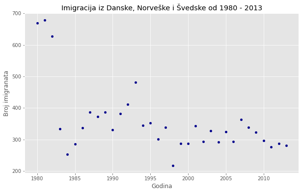

```python
 # generisanje scatter plot-a
df_total.plot(kind='scatter', x='year', y='total', figsize=(10, 6), color='darkblue')

#dodavanje naslova i labela za ose
plt.title('Imigracija iz Danske, Norveške i Švedske od 1980 - 2013')
plt.xlabel('Godina')
plt.ylabel('Broj imigranata')

# prikaz plota
plt.show()
```

Ovi rezultati podržavaju naše prethodne zaključke oko toga da je Skandinavljanima lepo na njihovim mestima.

### Bubble Plot

`Bubble plot` je unapređena verzija `Scatter plotova`. Scatter plot ima dve dimenzije, dok Bubble plot ima tri, i treća dimenzija se odnosi na težine. Stoga oni vizuelno prikazuju više informacija u odnosu na klasični Scatter plot. Tačke koje predstavljaju podatke zamenjene su mehuričima, i njihova vrednost određena je trećom dimenzijom.

Korak 1: Uzimanje podataka za Brazil and Argentinu. Konvertujemo `Years` da budu tipa int i postavljamo podatke u dataframe.

```python
df_can_t = df_can[years].transpose()
df_can_t.index = map(int, df_can_t.index)

# labela za index
df_can_t.index.name = 'Year'

# reset indeksa
df_can_t.reset_index(inplace=True)

# prikaz promena
df_can_t.head()
```

| Country | Year | Palau | Western Sahara | Marshall Islands | New Caledonia | San Marino | American Samoa | Tuvalu | Sao Tome and Principe | Vanuatu | ... | Poland | Republic of Korea | Sri Lanka | Iran (Islamic Republic of) | United States of America | Pakistan | Philippines | United Kingdom of Great Britain and Northern Ireland | China | India |
| --- | --- | --- | --- | --- | --- | --- | --- | --- | --- | --- | --- | --- | --- | --- | --- | --- | --- | --- | --- | --- | --- |
| 0 | 1980 | 0 | 0 | 0 | 0 | 1 | 0 | 0 | 0 | 0 | ... | 863 | 1011 | 185 | 1172 | 9378 | 978 | 6051 | 22045 | 5123 | 8880 |
| 1 | 1981 | 0 | 0 | 0 | 0 | 0 | 1 | 1 | 0 | 0 | ... | 2930 | 1456 | 371 | 1429 | 10030 | 972 | 5921 | 24796 | 6682 | 8670 |
| 2 | 1982 | 0 | 0 | 0 | 0 | 0 | 0 | 0 | 0 | 0 | ... | 5881 | 1572 | 290 | 1822 | 9074 | 1201 | 5249 | 20620 | 3308 | 8147 |
| 3 | 1983 | 0 | 0 | 0 | 0 | 0 | 0 | 0 | 0 | 0 | ... | 4546 | 1081 | 197 | 1592 | 7100 | 900 | 4562 | 10015 | 1863 | 7338 |
| 4 | 1984 | 0 | 0 | 0 | 0 | 0 | 0 | 1 | 0 | 0 | ... | 3588 | 847 | 1086 | 1977 | 6661 | 668 | 3801 | 10170 | 1527 | 5704 |

5 rows × 196 columns

Step 2: Kreiranje normalizovanih težina

Postoji nekoliko metoda normalizacije u statistici, svaki sa svojom upotrebom.Mi ćemo koristiti feature scaling kako bismo sve vrednosti sveli na opseg [0,1]. Formula je:

[figure not shown]

gde je *`X`* originalna vrednost,a *`X'`* normalizovana vrednost. Maksimalna vrednost je postavljena na 1, a minimalna na 0. Ostatak vrednosti je skaliran na odgovarajuće vrednosti između 0 i 1.

```python
# normalizovanje podataka za Brazil
norm_brazil = (df_can_t['Brazil'] - df_can_t['Brazil'].min()) / (df_can_t['Brazil'].max() - df_can_t['Brazil'].min())

# normalizovanje podataka za Argentinu
norm_argentina = (df_can_t['Argentina'] - df_can_t['Argentina'].min()) / (df_can_t['Argentina'].max() - df_can_t['Argentina'].min())
```

Korak 3: Iscrtavanje grafika.

- Iscrtavanje dva različita scatter plota na jednom,možemo imati iste ose zadavanjem`ax` parametra.
- Dodajemo i težinske koeficijente pomoću `s` parametra.Pošto su normalizovane težine između 0-1, one neće biti vidljive na grafiku. Zato ćemo
  - pomnožiti težine sa 2000 da ih prilagodino grafiku, i,
  - dodajemo 10 da bismo kompenzovali minimalnu vrednost (koja ima težinu nula i skalirana sa x2000).

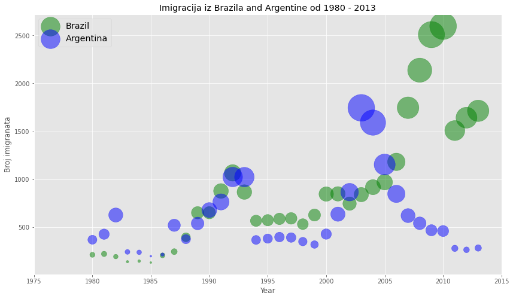

```python
# Brazil
ax0 = df_can_t.plot(kind='scatter',
                    x='Year',
                    y='Brazil',
                    figsize=(14, 8),
                    alpha=0.5,                  # transparentnost
                    color='green',
                    s=norm_brazil * 2000 + 10,  # prosleđivanje težinskih koeficijenata
                    xlim=(1975, 2015)
                   )

# Argentina
ax1 = df_can_t.plot(kind='scatter',
                    x='Year',
                    y='Argentina',
                    alpha=0.5,
                    color="blue",
                    s=norm_argentina * 2000 + 10,
                    ax = ax0
                   )

ax0.set_ylabel('Broj imigranata')
ax0.set_title('Imigracija iz Brazila and Argentine od 1980 - 2013')
ax0.legend(['Brazil', 'Argentina'], loc='upper left', fontsize='x-large')
```

Veličina mehura odgovara veličini imigrirajuće populacije za datu godinu, u poređenju sa podacima od 1980-2013 godine. Što je veći mehur, više migranata za tu godinu. Vidimo povećanje imigracije iz Argentine u kanadu tokom 1998-2002 koja se poklapa sa velikom depresijom. Vidimo sličan slučaj 1985-1993. Zapravo, Argentina je imala veliku depresiju of 1974-1990, pre započetka druge depresije od 1998-2002.

Slično, Brazil je prošao kroz *Samba Efekat* kada je brazilski real (valuta) opala za skoro 35% u vrednosti 1999. godine. Tada je postojao strah od južnoameričke finansijske krize pošto je mnogo zemalja Južne Amerike zavisilo od industrijskog izvoza iz Brazila. Brazilska vlada je nakon toga usvojila program zatezanja mera, i ekonomija se polako oporavljala kroz godine, kulminirajući nemirima 2010. Ovi podaci su odraz opisane situacije.

### Waffle Chart

Vafl tabela je jedna od neobičnih vizuelizacija koja prikazuje napredak ka cilju, odnosno procenat završetka. Sastoji se od mreže malih ćelija, od kojih podaci predstavljaju obojene ćelije.

Kvadratići su obojeni prema proporcijama koje želimo da vizualizujemo, slično onome kako bi različite kriške Pie charta bile obojene. Međutim, u poređenju sa Pie dijagramom, tabelu vafla je mnogo lakše čitati - naš mozak nije pogodan za upoređivanje različitih uglova i kriški, ali prilično lako možemo uporediti različite površine.

Grafikon se može sastojati od jedne ili nekoliko kategorija. Takođe može se spojiti nekoliko vafl grafika, kako bi se prikazalo poređenje različitih tabela.

Vafl grafik međutim nije sadržan ni u jednoj od Python biblioteka za vizuelizacije, zato ćemo u primeru napraviti funkciju za generisanje i prikaz Waffle Chart-a.

```python
import matplotlib.patches as mpatches
```

```python
# kreiramo novi dataframe koji će sadržati sledeće tri države, odnosno kategorije
df_dsn = df_can.loc[['Denmark', 'Norway', 'Sweden'], :]

# računamo učešće svake od ategorija koje posmatramo u ukupnoj vrednost
total_values = sum(df_dsn['Total'])
category_proportions = [(float(value) / total_values) for value in df_dsn['Total']]

# prikazujemo procenat svake kategorije
for i, proportion in enumerate(category_proportions):
    print (df_dsn.index.values[i] + ': ' + str(proportion))
```

```
Denmark: 0.32255663965602777
Norway: 0.1924094592359848
Sweden: 0.48503390110798744
```

```python
width = 40 # visina grafika
height = 10 # širina grafika

total_num_tiles = width * height # ukupan broj ćelija
```

```python
# računamo broj ćelija za svaku od kategorija
tiles_per_category = [round(proportion * total_num_tiles) for proportion in category_proportions]

# prikazujemo broj ćelija koji će biti dodeljen svakoj kategoriji
for i, tiles in enumerate(tiles_per_category):
    print (df_dsn.index.values[i] + ': ' + str(tiles))
```

```
Denmark: 129
Norway: 77
Sweden: 194
```

```python
# inicijalizujemo waffle chart kao praznu matricu
waffle_chart = np.zeros((height, width))

# definišemo indekse kako bismo mogli da petljom prođemo kroz waffle chart
category_index = 0
tile_index = 0

# popunjavamo waffle chart
for col in range(width):
    for row in range(height):
        tile_index += 1

        # ako je broj trenutno dodeljenih polja tekućoj kategoriji jednak ukupnom broju ćelija koje joj mogu biti dodeljene..
        if tile_index > sum(tiles_per_category[0:category_index]):
            # ...petja prelazi na sledeću kategoriju
            category_index += 1

        # vrednost u koloni setujemo na broj koji odgovara datoj klasi
        waffle_chart[row, col] = category_index

print ('Waffle chart je uspešno popunjen!')
```

```
Waffle chart je uspešno popunjen!
```

```python
waffle_chart #možemo da pogledamo kako matrica trenutno izgleda
```

```
array([[1., 1., 1., 1., 1., 1., 1., 1., 1., 1., 1., 1., 1., 2., 2., 2.,
        2., 2., 2., 2., 2., 3., 3., 3., 3., 3., 3., 3., 3., 3., 3., 3.,
        3., 3., 3., 3., 3., 3., 3., 3.],
       [1., 1., 1., 1., 1., 1., 1., 1., 1., 1., 1., 1., 1., 2., 2., 2.,
        2., 2., 2., 2., 2., 3., 3., 3., 3., 3., 3., 3., 3., 3., 3., 3.,
        3., 3., 3., 3., 3., 3., 3., 3.],
       [1., 1., 1., 1., 1., 1., 1., 1., 1., 1., 1., 1., 1., 2., 2., 2.,
        2., 2., 2., 2., 2., 3., 3., 3., 3., 3., 3., 3., 3., 3., 3., 3.,
        3., 3., 3., 3., 3., 3., 3., 3.],
       [1., 1., 1., 1., 1., 1., 1., 1., 1., 1., 1., 1., 1., 2., 2., 2.,
        2., 2., 2., 2., 2., 3., 3., 3., 3., 3., 3., 3., 3., 3., 3., 3.,
        3., 3., 3., 3., 3., 3., 3., 3.],
       [1., 1., 1., 1., 1., 1., 1., 1., 1., 1., 1., 1., 1., 2., 2., 2.,
        2., 2., 2., 2., 2., 3., 3., 3., 3., 3., 3., 3., 3., 3., 3., 3.,
        3., 3., 3., 3., 3., 3., 3., 3.],
       [1., 1., 1., 1., 1., 1., 1., 1., 1., 1., 1., 1., 1., 2., 2., 2.,
        2., 2., 2., 2., 2., 3., 3., 3., 3., 3., 3., 3., 3., 3., 3., 3.,
        3., 3., 3., 3., 3., 3., 3., 3.],
       [1., 1., 1., 1., 1., 1., 1., 1., 1., 1., 1., 1., 1., 2., 2., 2.,
        2., 2., 2., 2., 3., 3., 3., 3., 3., 3., 3., 3., 3., 3., 3., 3.,
        3., 3., 3., 3., 3., 3., 3., 3.],
       [1., 1., 1., 1., 1., 1., 1., 1., 1., 1., 1., 1., 1., 2., 2., 2.,
        2., 2., 2., 2., 3., 3., 3., 3., 3., 3., 3., 3., 3., 3., 3., 3.,
        3., 3., 3., 3., 3., 3., 3., 3.],
       [1., 1., 1., 1., 1., 1., 1., 1., 1., 1., 1., 1., 1., 2., 2., 2.,
        2., 2., 2., 2., 3., 3., 3., 3., 3., 3., 3., 3., 3., 3., 3., 3.,
        3., 3., 3., 3., 3., 3., 3., 3.],
       [1., 1., 1., 1., 1., 1., 1., 1., 1., 1., 1., 1., 2., 2., 2., 2.,
        2., 2., 2., 2., 3., 3., 3., 3., 3., 3., 3., 3., 3., 3., 3., 3.,
        3., 3., 3., 3., 3., 3., 3., 3.]])
```

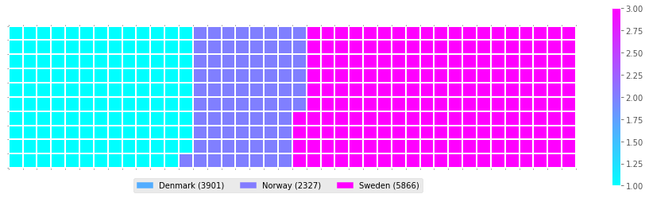

```python
# instanciramo novi objekat figuru
fig = plt.figure()

# koristimo funkciju matshow da prikažemo grafik
colormap = plt.cm.cool
plt.matshow(waffle_chart, cmap=colormap)
plt.colorbar()

# uzimamo osu
ax = plt.gca()

# postavljamo korake
ax.set_xticks(np.arange(-.5, (width), 1), minor=True)
ax.set_yticks(np.arange(-.5, (height), 1), minor=True)

# dodajemo ivice kvadratićima
ax.grid(which='minor', color='w', linestyle='-', linewidth=2)

plt.xticks([])
plt.yticks([])

# kumulativne sume individualnih kategorija koje ćemo prikazati u legendi
values_cumsum = np.cumsum(df_dsn['Total'])
total_values = values_cumsum[len(values_cumsum) - 1]

# kreiramo legendu
legend_handles = []
for i, category in enumerate(df_dsn.index.values):
    label_str = category + ' (' + str(df_dsn['Total'][i]) + ')'
    color_val = colormap(float(values_cumsum[i])/total_values)
    legend_handles.append(mpatches.Patch(color=color_val, label=label_str))

# dodajemo legendu na grafik
plt.legend(handles=legend_handles,
           loc='lower center',
           ncol=len(df_dsn.index.values),
           bbox_to_anchor=(0., -0.2, 0.95, .1)
          )
```

Iako bismo na prvi pogled iz datog grafika zaključili da je najveći procenat odlaska stanovnika iz Skandinavskih zemalja najveći iz Švdeske, bitno je imati u vidu informaciju da grafik prikazuje udeo u ukupnom odlasku stanovnika iz skandinavije, a ne iz svake zemlje ponaosob. Kada u obzir uzmemo i podatke o populaciji, Danska:Norveška:Švedska možemo primetiti da su ove 3 države i u tom slučaju u dosta sličnom odnosu kao na grafiku ~ 3:2:5

## Seaborn

Seaborn je još jedna od Python biblioteka za vizuelizaciju, takođe zasnovana na matplotlib biblioteci i integrisana sa pandas bibliotekom i njenim strukturama podataka. Pruža interfejs na visokom nivou za crtanje statističkih grafika.

Pomaže u istraživanju i razumevanju podataka. Njene funkcije crtanja rade na dataframeovima i nizovima koji sadrže čitave datasetove i interno izvode potrebno semantičko mapiranje i statističko agregiranje za dobijanje informativnih grafikona. Deklarativni API orijentisan na skup podataka omogućava usresređenost na značenje različitih elemenata grafika, a ne na detalje o tome kako ih nacrtati.

U sledećem primeru ćemo probati da prikažemo kompaktnost seaborn biblioteke. Korišćenjem matplotlib biblioteke već smo crtali scatter plot i prikazali regresiju, za šta je bilo potrebno 20ak linija koda, dok je u seabornu to je moguće uraditi korišćenjem samo jedne funkcije.

Prvo je neophodno instalirati i importovati seaborn biblioteku

```python
# install seaborn
!conda install -c anaconda seaborn --yes

# import library
import seaborn as sns

print('Seaborn je uspešno instaliran i importovan')
```

```
Solving environment: ...working... done

# All requested packages already installed.

Seaborn je uspešno instaliran i importovan
```

```python
# korišćenjem sum() metode izračunaćemo ukupan broj migracija tokom svake godine
df_tot = pd.DataFrame(df_can[years].sum(axis=0))

# promenićemo tip podatka godine u float (što će u kasnijim koracima biti korisno za regresiju)
df_tot.index = map(float, df_tot.index)
df_tot.reset_index(inplace=True)
df_tot.columns = ['year', 'total']

# novi dataframe
df_tot.head()
```

|  | year | total |
| --- | --- | --- |
| 0 | 1980.0 | 99137 |
| 1 | 1981.0 | 110563 |
| 2 | 1982.0 | 104271 |
| 3 | 1983.0 | 75550 |
| 4 | 1984.0 | 73417 |

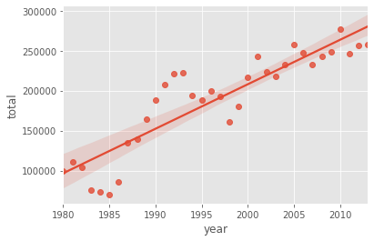

```python
ax = sns.regplot(x='year', y='total', data=df_tot)
```

Korišćenjem ostalih parametara regplot funkcije možemo prilagoditi i izmeniti izgled grafika

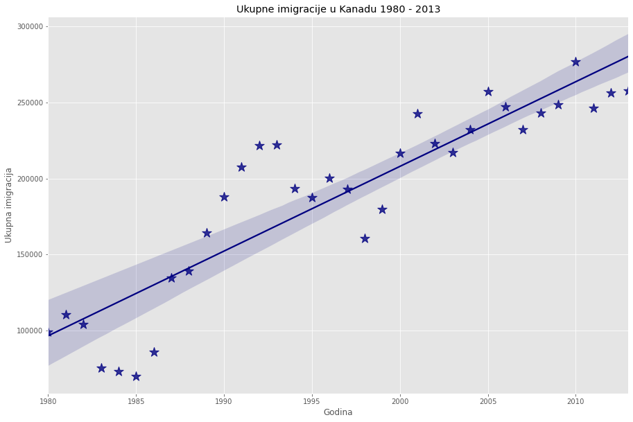

```python
plt.figure(figsize=(15, 10))
ax = sns.regplot(x='year', y='total', data=df_tot, color='navy', marker='*', scatter_kws={'s': 200})

ax.set(xlabel='Godina', ylabel='Ukupna imigracija')
ax.set_title('Ukupne imigracije u Kanadu 1980 - 2013')
```

## Folium

Folium je jedna od Python biblioteka za vizuelizaciju podataka, razvijena sa glavnom svrhom vizuelizacije geoprostornih podataka. Iako su druge biblioteke dostupne za vizuelizaciju geoprostornih podataka, kao što je na primer Plotly, one mogu imati ograničenje broja API poziva koje možete uputiti u definisanom vremenskom okviru. Folium je, pak, potpuno besplatan.

Folium je moćna Python biblioteka koja pomaže u kreiranju nekoliko vrsta mapa. Činjenica da su rezultati Foliuma interaktivni čini ovu biblioteku veoma korisnom za izgradnju kontrolne table. Folium je Python wrapper za Leaflet.js koji je vodeća JavaScript biblioteka otvorenog koda za crtanje interaktivnih mapa.

Sa zvanične stranice dokumentacije Folium:

- Folium se nadovezuje na snagu manipulisanja podataka koju ima Python i na snagu mapiranja biblioteke Leaflet.js. Manipulišite podacima u Pithonu, a zatim ih vizualizujte na mapi preko Foliuma.
- Folium olakšava vizuelizaciju podataka kojima se manipuliše u Pithonu na interaktivnoj mapi. Omogućava vezivanje podataka za mapu za vizualizaciju choropleth-a, kao i prosleđivanje Vincent / Vega vizualizacija kao markera na mapi.
- Biblioteka ima brojne ugrađene tilesetove iz OpenStreetMap, Mapbok i Stamen, a podržava prilagođene skupove pločica sa Mapbok ili Cloudmade API ključevima. Folium podržava i GeoJSON i TopoJSON overlay-ove, kao i vezivanje podataka za njih kako bi se kreirale mape choropleth-a.

Folium nije dostupan po defaultu, dakle prvo ga moramo instalirati pre nego što ga importujemo

```python
!conda install -c conda-forge folium=0.5.0 --yes
import folium

print('Folium je uspešno instaliran i importovan')
```

[output not shown]

Generisanje mape sveta je u Foliumu jednostavno. Potrebno je napraviti objekat Folium Map, a zatim ga prikazati. Ono što je prednost kod mapa Folium je to što su interaktivne, tako da je moguće zumirati bilo koji region od interesa uprkos početnom nivou zumiranja.

Sve lokacije na mapi su definisane odgovarajućim vrednostima širine i dužine. Tako se može napraviti mapa i postaviti u centar vrednosti geografskih širina i dužina od [0, 0].

Za definisani centar takođe možete da definišete nivo početnog zuma na toj lokaciji kada se karta prikazuje. Što je veći nivo zumiranja, karta je više zumirana u centar.

Još jedna odlična karakteristika Foliuma je što može generisati različite stilove mapa.

Tileset je kolekcija rasterskih i vektorskih podataka podeljenih u jedinstvenu mrežu kvadratnih pločica. Svaki skup pločica ima drugačiji način predstavljanja podataka na mapi. Folium nam omogućava da kreiramo mape sa različitim pločicama poput Stamen Terrain, Stamen Toner, Stamen Vater Colour, CartoDB Positron i mnogih drugih. Podrazumevano su pločice postavljene na OpenStreetMap.

Svaka pločica prikazuje različite karakteristike mape i pogodna je za različite svrhe. Na primer, Stamen Terrain ima senke na brdima i prirodne boje vegetacije. Prikazuje napredna obeležavanja i generalizovanost linija dvostrukih kolovoza. I, CartoDB Dark Matter prikazuje CartoDB Positron mapu u mračnom režimu.

Budući da svaki skup pločica pruža informacije na drugačiji način i ima drugačiju svrhu, možemo ih postaviti u slejevima jedan preko drugog da bismo dobili više informacija samo crtanjem jedne karte. To možemo učiniti dodavanjem različitih slojeva pločica na jednu mapu

Veličinu karte možemo promeniti pomoću biblioteke branca u Pythonu. To je nastavak Foliuma koje je domaćin karakteristikama koje nisu specifične za mapu. Klasu Figure možemo koristiti za promenu veličine naših mapa i prosleđivanje željene širine i visine u pikselima

```python
from branca.element import Figure
```

```python
fig=Figure(width=650,height=450)
canada_map = folium.Map(location=[56.130, -106.35],zoom_start=4)
fig.add_child(canada_map)
folium.TileLayer('cartodbpositron').add_to(canada_map)
folium.TileLayer('cartodbdark_matter').add_to(canada_map)
folium.TileLayer('Stamen Water Color').add_to(canada_map)
folium.TileLayer('Stamen Terrain').add_to(canada_map)
folium.TileLayer('Stamen Toner').add_to(canada_map)
folium.LayerControl().add_to(canada_map)

#prikazujemo mapu
canada_map
```

[interactive chart not shown]

### Choropleth mapa

Karta Choropleth-a je tematska karta na kojoj su područja osenčena ili šrafirana proporcionalno vrednosti statističke promenljive koja se prikazuje na mapi, poput gustine naseljenosti ili dohotka po stanovniku. Karta choropletha pruža jednostavan način da se vizualizuje kako merenje varira u geografskom području ili pokazuje nivo promenljivosti unutar regiona.

Da bismo kreirali mapu Choropleth, potreban nam je GeoJSON fajl koji definiše područja / granice države, okruga ili države koja nas zanima. U našem slučaju, s obzirom da nastojimo da napravimo mapu sveta, želimo GeoJSON koji definiše granice svih svetskih zemalja.

```python
world_geo = r'data/world_countries.json' #učitavamo json fajl
```

```python
world_map = folium.Map(location=[0, 0], zoom_start=2)
```

Kako bismo kreirali mapu Choropleth, koristićemo metodu choropleth sa sledećim glavnim parametrima:

- geo_data - što je datoteka GeoJSON.
- data - što je dataframe koji sadrži podatke.
- columns - koja predstavlja kolone u okviru podataka koji će se koristiti za kreiranje mape Choropleth.
- key_on - što je ključ ili promenljiva u datoteci GeoJSON koja sadrži ime promenljive koja nas zanima. Potrebno je znati ime ključa ili promenljive koja sadrži ime zemalja, jer su države naša promenljiva od interesa. U ovom slučaju, name je ključ u datoteci GeoJSON koji sadrži ime zemalja. Važno je imati na umu da je ovaj ključ osetljiv na velika i mala slova, pa se mora proslediti tačno onakav kakav postoji u datoteci GeoJSON.

```python
# generišemo choropleth mapu koristeći podatke o ukupnom broju migracija iz svake države u Kanadu za 2013. godinu
world_map.choropleth(
    geo_data=world_geo,
    data=df_can.reset_index(),
    columns=['Country', 'Total'],
    key_on='feature.properties.name',
    fill_color='YlOrRd',
    fill_opacity=0.7,
    line_opacity=0.2,
    legend_name='Imigracije u Kanadu'
)

# prikaz mape
world_map
```

Make this Notebook Trusted to load map: File -> Trust Notebook

[interactive chart not shown]

Prema našoj legendi karte Choropleth, što je tamnija boja neke zemlje i što je boja bliža crvenoj, to je veći broj doseljenika iz te zemlje. Shodno tome, najveća imigracija tokom 33 godine (od 1980. do 2013.) bila je iz Kine, Indije i Filipina, zatim iz Poljske, Pakistana i SAD.

Možemo primetiti kako legenda prikazuje negativnu granicu ili prag. Ispravićemo to tako što ćemo definisati sopstvene pragove i započeti sa 0 umesto sa -6918

```python
world_geo = r'data/world_countries.json' #učitavamo json fajl
# kreiramo numpy niz dužine 6 koji ima linearan razmak između najmanje i najveće vrednost kolone Total
threshold_scale = np.linspace(df_can['Total'].min(),
                              df_can['Total'].max(),
                              6, dtype=int)
threshold_scale = threshold_scale.tolist() # konvertujemo numpy niz u listu
threshold_scale[-1] = threshold_scale[-1] + 1 # potvrđujemo da je poslednja vrednost u listi veća od max vrednosti ukupnih migracija

# prepuštamo Folium-u da utvrdi skalu
world_map = folium.Map(location=[0, 0], zoom_start=2)
world_map.choropleth(
    geo_data=world_geo,
    data=df_can.reset_index(),
    columns=['Country', 'Total'],
    key_on='feature.properties.name',
    threshold_scale=threshold_scale,
    fill_color='YlOrRd',
    fill_opacity=0.7,
    line_opacity=0.2,
    legend_name='Imigracije u Kanadu',
    reset=True
)
world_map
```

Make this Notebook Trusted to load map: File -> Trust Notebook

[interactive chart not shown]